# Project: Introduction to Neural Networks: ReneWind

## Context

Renewable energy sources play an increasingly important role in the global energy mix, as the effort to reduce the environmental impact of energy production increases.

Out of all the renewable energy alternatives, wind energy is one of the most developed technologies worldwide. The U.S. Department of Energy has put together a guide to achieving operational efficiency using predictive maintenance practices.

Predictive maintenance uses sensor information and analysis methods to measure and predict degradation and future component capability. The idea behind predictive maintenance is that failure patterns are predictable and if component failure can be predicted accurately and the component is replaced before it fails, the costs of operation and maintenance will be much lower.

The sensors fitted across different machines involved in the process of energy generation collect data related to various environmental factors (temperature, humidity, wind speed, etc.) and additional features related to various parts of the wind turbine (gearbox, tower, blades, break, etc.).

## Objective

“ReneWind” is a company working on improving the machinery/processes involved in the production of wind energy using machine learning and has collected data on generator failure of wind turbines using sensors. They have shared a ciphered version of the data, as the data collected through sensors is confidential (the type of data collected varies with companies). Data has 40 predictors, 20000 observations in the training set, and 5000 in the test set. The objective is to build various classification models, tune them, and find the best one that will help identify failures so that the generators can be repaired before failing/breaking to reduce the overall maintenance cost.

The nature of predictions made by the classification model will translate as follows:

- True positives (TP) are failures correctly predicted by the model. These will result in repair costs.
- False negatives (FN) are real failures where there is no detection by the model. These will result in replacement costs.
- False positives (FP) are detections where there is no failure. These will result in inspection costs.

It is given that the cost of repairing a generator is much less than the cost of replacing it, and the cost of inspection is less than the cost of repair.

Note:

- Inspection Cost < Repair Cost < Replacement Cost
- “1” in the target variable should be considered as “failure” and “0” represents “No failure”.

### Data Description

The data provided is a transformed version of the original data which was collected using sensors.

- Train.csv - To be used for training and tuning of models.
- Test.csv - To be used only for testing the performance of the final best model.

Both datasets consist of 40 predictor variables and 1 target variable.

## Key Goals Or Problems to be solved:

The objective is to

1. **Solve**: Build various classification models, tune them, and find the best one that will help **identify failures** so that the generators can be repaired before failing/breaking to reduce the overall maintenance cost.
- Note: “1” in the target variable should be considered as “failure” and “0” represents “No failure”.
1. **Evaluate**: The nature of predictions made by the classification model will translate as follows:
- True positives (TP) are failures correctly predicted by the model. These will result in repair costs.
- False negatives (FN) are real failures where there is no detection by the model. These will result in replacement costs.
- False positives (FP) are detections where there is no failure. These will result in inspection costs.
1. **Optimize**: It is given that :
- Inspection Cost < Repair Cost < Replacement Cost

### Importing the required libraries

```python
#Installing the libraries with specific versions
!pip install  tensorflow==2.18.0 scikit-learn==1.3.2 matplotlib===3.8.3 seaborn==0.13.2 numpy==1.26.4 pandas==2.2.2   -q --user --no-warn-script-location
```

```python
# To help with reading and manipulation of data
import numpy as np
from numpy import array
import pandas as pd

# To help with data visualization
import matplotlib.pyplot as plt
import seaborn as sns

# To split the data
from sklearn.model_selection import train_test_split

# To impute missing values
from sklearn.impute import SimpleImputer

# To do one-hot encoding
from sklearn.preprocessing import OneHotEncoder

# Module for time-related operations.
import time

#Modules for Neural Network Model building
import tensorflow as tf #An end-to-end open source machine learning platform
from tensorflow import keras  # High-level neural networks API for deep learning.
from keras import backend   # Abstraction layer for neural network backend engines.
from keras.models import Sequential  # Model for building NN sequentially.
from keras.layers import Dense,Dropout,BatchNormalization   # for creating fully connected neural network layers.

# To get different performance metrics
import sklearn.metrics as metrics
from sklearn.metrics import (
    classification_report,
    confusion_matrix,
    recall_score,
    accuracy_score,
    precision_score,
    f1_score,
)
from sklearn.model_selection import RandomizedSearchCV

# To undersample and oversample the data
from imblearn.over_sampling import SMOTE
from imblearn.under_sampling import RandomUnderSampler
from imblearn.pipeline import Pipeline
from sklearn.model_selection import GridSearchCV, StratifiedKFold

# To suppress warnings
import warnings
warnings.filterwarnings("ignore")
```

## Data Overview

### Loading the Data and Reviewing it

```python
from google.colab import drive
drive.mount('/content/drive')
```

```python
# loading Training data into a dataframe
path='/content/drive/MyDrive/Learnings/Python_Saved_Path/ReneWind-Train.csv'
reneWind=pd.read_csv(path)

# creating a copy of the Training data
data_train=reneWind.copy()

# loading Test data into a dataframe
path='/content/drive/MyDrive/Learnings/Python_Saved_Path/ReneWind-Test.csv'
reneWindTest=pd.read_csv(path)

# creating a copy of the Test data
data_test=reneWindTest.copy()
```

```python
#reading the data
data_train.head()
```

|  | V1 | V2 | V3 | V4 | V5 | V6 | V7 | V8 | V9 | V10 | ... | V32 | V33 | V34 | V35 | V36 | V37 | V38 | V39 | V40 | Target |
| --- | --- | --- | --- | --- | --- | --- | --- | --- | --- | --- | --- | --- | --- | --- | --- | --- | --- | --- | --- | --- | --- |
| 0 | -4.464606 | -4.679129 | 3.101546 | 0.506130 | -0.221083 | -2.032511 | -2.910870 | 0.050714 | -1.522351 | 3.761892 | ... | 3.059700 | -1.690440 | 2.846296 | 2.235198 | 6.667486 | 0.443809 | -2.369169 | 2.950578 | -3.480324 | 0 |
| 1 | 3.365912 | 3.653381 | 0.909671 | -1.367528 | 0.332016 | 2.358938 | 0.732600 | -4.332135 | 0.565695 | -0.101080 | ... | -1.795474 | 3.032780 | -2.467514 | 1.894599 | -2.297780 | -1.731048 | 5.908837 | -0.386345 | 0.616242 | 0 |
| 2 | -3.831843 | -5.824444 | 0.634031 | -2.418815 | -1.773827 | 1.016824 | -2.098941 | -3.173204 | -2.081860 | 5.392621 | ... | -0.257101 | 0.803550 | 4.086219 | 2.292138 | 5.360850 | 0.351993 | 2.940021 | 3.839160 | -4.309402 | 0 |
| 3 | 1.618098 | 1.888342 | 7.046143 | -1.147285 | 0.083080 | -1.529780 | 0.207309 | -2.493629 | 0.344926 | 2.118578 | ... | -3.584425 | -2.577474 | 1.363769 | 0.622714 | 5.550100 | -1.526796 | 0.138853 | 3.101430 | -1.277378 | 0 |
| 4 | -0.111440 | 3.872488 | -3.758361 | -2.982897 | 3.792714 | 0.544960 | 0.205433 | 4.848994 | -1.854920 | -6.220023 | ... | 8.265896 | 6.629213 | -10.068689 | 1.222987 | -3.229763 | 1.686909 | -2.163896 | -3.644622 | 6.510338 | 0 |

5 rows × 41 columns

```python
data_train.tail()
```

|  | V1 | V2 | V3 | V4 | V5 | V6 | V7 | V8 | V9 | V10 | ... | V32 | V33 | V34 | V35 | V36 | V37 | V38 | V39 | V40 | Target |
| --- | --- | --- | --- | --- | --- | --- | --- | --- | --- | --- | --- | --- | --- | --- | --- | --- | --- | --- | --- | --- | --- |
| 19995 | -2.071318 | -1.088279 | -0.796174 | -3.011720 | -2.287540 | 2.807310 | 0.481428 | 0.105171 | -0.586599 | -2.899398 | ... | -8.273996 | 5.745013 | 0.589014 | -0.649988 | -3.043174 | 2.216461 | 0.608723 | 0.178193 | 2.927755 | 1 |
| 19996 | 2.890264 | 2.483069 | 5.643919 | 0.937053 | -1.380870 | 0.412051 | -1.593386 | -5.762498 | 2.150096 | 0.272302 | ... | -4.159092 | 1.181466 | -0.742412 | 5.368979 | -0.693028 | -1.668971 | 3.659954 | 0.819863 | -1.987265 | 0 |
| 19997 | -3.896979 | -3.942407 | -0.351364 | -2.417462 | 1.107546 | -1.527623 | -3.519882 | 2.054792 | -0.233996 | -0.357687 | ... | 7.112162 | 1.476080 | -3.953710 | 1.855555 | 5.029209 | 2.082588 | -6.409304 | 1.477138 | -0.874148 | 0 |
| 19998 | -3.187322 | -10.051662 | 5.695955 | -4.370053 | -5.354758 | -1.873044 | -3.947210 | 0.679420 | -2.389254 | 5.456756 | ... | 0.402812 | 3.163661 | 3.752095 | 8.529894 | 8.450626 | 0.203958 | -7.129918 | 4.249394 | -6.112267 | 0 |
| 19999 | -2.686903 | 1.961187 | 6.137088 | 2.600133 | 2.657241 | -4.290882 | -2.344267 | 0.974004 | -1.027462 | 0.497421 | ... | 6.620811 | -1.988786 | -1.348901 | 3.951801 | 5.449706 | -0.455411 | -2.202056 | 1.678229 | -1.974413 | 0 |

5 rows × 41 columns

```python
data_train.sample(5)
```

|  | V1 | V2 | V3 | V4 | V5 | V6 | V7 | V8 | V9 | V10 | ... | V32 | V33 | V34 | V35 | V36 | V37 | V38 | V39 | V40 | Target |
| --- | --- | --- | --- | --- | --- | --- | --- | --- | --- | --- | --- | --- | --- | --- | --- | --- | --- | --- | --- | --- | --- |
| 8220 | 0.081333 | 0.327539 | 6.424742 | 3.386782 | -0.828140 | -5.217039 | -0.929747 | 3.028016 | -1.071861 | 0.654633 | ... | 1.868828 | -4.554222 | 2.517343 | 5.022805 | 3.301697 | -0.442219 | -4.021128 | 0.543624 | -2.343309 | 0 |
| 9580 | 3.907464 | 1.937588 | 8.579712 | 2.317480 | -2.327744 | -2.617536 | -1.882511 | -3.359826 | 2.277938 | 0.831551 | ... | -1.967430 | -0.929446 | 0.148309 | 7.886119 | 0.972492 | -2.516696 | -1.050896 | 0.819626 | -4.021882 | 0 |
| 10817 | 2.155239 | 4.607938 | 0.925883 | 6.233707 | -2.053192 | 1.470696 | -1.704652 | -7.362534 | 3.705898 | -1.390128 | ... | -0.527332 | 4.955084 | -0.609979 | 8.316364 | -10.091514 | -2.766304 | 8.335463 | -1.999190 | -5.776892 | 0 |
| 8463 | -7.002193 | 0.372190 | 1.443017 | 3.578736 | 2.935654 | -1.605792 | -4.676769 | -2.660901 | 0.229007 | 1.314029 | ... | 13.222413 | 5.815618 | -3.247733 | 6.137743 | 1.681867 | -1.372565 | 0.710406 | 1.941902 | -7.172066 | 0 |
| 11596 | 6.464817 | -3.089916 | -1.021220 | -8.431801 | -3.395713 | 1.225529 | 2.183519 | 1.011530 | -1.263735 | 1.196396 | ... | -5.358958 | -1.630994 | -0.544251 | 0.469533 | 2.788549 | 0.924196 | -1.533849 | 0.509330 | 2.636759 | 0 |

5 rows × 41 columns

```python
data_train.shape
```

```
(20000, 41)
```

```python
data_train.info()
```

```
<class 'pandas.core.frame.DataFrame'>
RangeIndex: 20000 entries, 0 to 19999
Data columns (total 41 columns):
 #   Column  Non-Null Count  Dtype
---  ------  --------------  -----
 0   V1      19982 non-null  float64
 1   V2      19982 non-null  float64
 2   V3      20000 non-null  float64
 3   V4      20000 non-null  float64
 4   V5      20000 non-null  float64
 5   V6      20000 non-null  float64
 6   V7      20000 non-null  float64
 7   V8      20000 non-null  float64
 8   V9      20000 non-null  float64
 9   V10     20000 non-null  float64
```

[output cut: 33 more lines]

```python
# Getting the statistical summary of the data
data_train.describe(include='all').T
```

|  | count | mean | std | min | 25% | 50% | 75% | max |
| --- | --- | --- | --- | --- | --- | --- | --- | --- |
| V1 | 19982.0 | -0.271996 | 3.441625 | -11.876451 | -2.737146 | -0.747917 | 1.840112 | 15.493002 |
| V2 | 19982.0 | 0.440430 | 3.150784 | -12.319951 | -1.640674 | 0.471536 | 2.543967 | 13.089269 |
| V3 | 20000.0 | 2.484699 | 3.388963 | -10.708139 | 0.206860 | 2.255786 | 4.566165 | 17.090919 |
| V4 | 20000.0 | -0.083152 | 3.431595 | -15.082052 | -2.347660 | -0.135241 | 2.130615 | 13.236381 |
| V5 | 20000.0 | -0.053752 | 2.104801 | -8.603361 | -1.535607 | -0.101952 | 1.340480 | 8.133797 |
| V6 | 20000.0 | -0.995443 | 2.040970 | -10.227147 | -2.347238 | -1.000515 | 0.380330 | 6.975847 |
| V7 | 20000.0 | -0.879325 | 1.761626 | -7.949681 | -2.030926 | -0.917179 | 0.223695 | 8.006091 |
| V8 | 20000.0 | -0.548195 | 3.295756 | -15.657561 | -2.642665 | -0.389085 | 1.722965 | 11.679495 |
| V9 | 20000.0 | -0.016808 | 2.160568 | -8.596313 | -1.494973 | -0.067597 | 1.409203 | 8.137580 |
| V10 | 20000.0 | -0.012998 | 2.193201 | -9.853957 | -1.411212 | 0.100973 | 1.477045 | 8.108472 |
| V11 | 20000.0 | -1.895393 | 3.124322 | -14.832058 | -3.922404 | -1.921237 | 0.118906 | 11.826433 |
| V12 | 20000.0 | 1.604825 | 2.930454 | -12.948007 | -0.396514 | 1.507841 | 3.571454 | 15.080698 |
| V13 | 20000.0 | 1.580486 | 2.874658 | -13.228247 | -0.223545 | 1.637185 | 3.459886 | 15.419616 |
| V14 | 20000.0 | -0.950632 | 1.789651 | -7.738593 | -2.170741 | -0.957163 | 0.270677 | 5.670664 |
| V15 | 20000.0 | -2.414993 | 3.354974 | -16.416606 | -4.415322 | -2.382617 | -0.359052 | 12.246455 |
| V16 | 20000.0 | -2.925225 | 4.221717 | -20.374158 | -5.634240 | -2.682705 | -0.095046 | 13.583212 |
| V17 | 20000.0 | -0.134261 | 3.345462 | -14.091184 | -2.215611 | -0.014580 | 2.068751 | 16.756432 |
| V18 | 20000.0 | 1.189347 | 2.592276 | -11.643994 | -0.403917 | 0.883398 | 2.571770 | 13.179863 |
| V19 | 20000.0 | 1.181808 | 3.396925 | -13.491784 | -1.050168 | 1.279061 | 3.493299 | 13.237742 |
| V20 | 20000.0 | 0.023608 | 3.669477 | -13.922659 | -2.432953 | 0.033415 | 2.512372 | 16.052339 |
| V21 | 20000.0 | -3.611252 | 3.567690 | -17.956231 | -5.930360 | -3.532888 | -1.265884 | 13.840473 |
| V22 | 20000.0 | 0.951835 | 1.651547 | -10.122095 | -0.118127 | 0.974687 | 2.025594 | 7.409856 |
| V23 | 20000.0 | -0.366116 | 4.031860 | -14.866128 | -3.098756 | -0.262093 | 2.451750 | 14.458734 |
| V24 | 20000.0 | 1.134389 | 3.912069 | -16.387147 | -1.468062 | 0.969048 | 3.545975 | 17.163291 |
| V25 | 20000.0 | -0.002186 | 2.016740 | -8.228266 | -1.365178 | 0.025050 | 1.397112 | 8.223389 |
| V26 | 20000.0 | 1.873785 | 3.435137 | -11.834271 | -0.337863 | 1.950531 | 4.130037 | 16.836410 |
| V27 | 20000.0 | -0.612413 | 4.368847 | -14.904939 | -3.652323 | -0.884894 | 2.189177 | 17.560404 |
| V28 | 20000.0 | -0.883218 | 1.917713 | -9.269489 | -2.171218 | -0.891073 | 0.375884 | 6.527643 |
| V29 | 20000.0 | -0.985625 | 2.684365 | -12.579469 | -2.787443 | -1.176181 | 0.629773 | 10.722055 |
| V30 | 20000.0 | -0.015534 | 3.005258 | -14.796047 | -1.867114 | 0.184346 | 2.036229 | 12.505812 |
| V31 | 20000.0 | 0.486842 | 3.461384 | -13.722760 | -1.817772 | 0.490304 | 2.730688 | 17.255090 |
| V32 | 20000.0 | 0.303799 | 5.500400 | -19.876502 | -3.420469 | 0.052073 | 3.761722 | 23.633187 |
| V33 | 20000.0 | 0.049825 | 3.575285 | -16.898353 | -2.242857 | -0.066249 | 2.255134 | 16.692486 |
| V34 | 20000.0 | -0.462702 | 3.183841 | -17.985094 | -2.136984 | -0.255008 | 1.436935 | 14.358213 |
| V35 | 20000.0 | 2.229620 | 2.937102 | -15.349803 | 0.336191 | 2.098633 | 4.064358 | 15.291065 |
| V36 | 20000.0 | 1.514809 | 3.800860 | -14.833178 | -0.943809 | 1.566526 | 3.983939 | 19.329576 |
| V37 | 20000.0 | 0.011316 | 1.788165 | -5.478350 | -1.255819 | -0.128435 | 1.175533 | 7.467006 |
| V38 | 20000.0 | -0.344025 | 3.948147 | -17.375002 | -2.987638 | -0.316849 | 2.279399 | 15.289923 |
| V39 | 20000.0 | 0.890653 | 1.753054 | -6.438880 | -0.272250 | 0.919261 | 2.057540 | 7.759877 |
| V40 | 20000.0 | -0.875630 | 3.012155 | -11.023935 | -2.940193 | -0.920806 | 1.119897 | 10.654265 |
| Target | 20000.0 | 0.055500 | 0.228959 | 0.000000 | 0.000000 | 0.000000 | 0.000000 | 1.000000 |

### Observations

- Data Dimensions: The training dataset (data_train) contains 20,000 observations and 41 columns (V1-V40 and Target).
- Data Types: All predictor variables (V1-V40) are of float64 type, while the target variable (Target) is of int64 type.
- Target Variable Imbalance: The 'Target' variable has a mean of approximately 0.0555, indicating that only about 5.55% of the training data represents 'failure' (class 1), suggesting a significant class imbalance.
- Missing Values: Columns V1 and V2 in the data_train DataFrame each have 18 missing values.

## Data Preprocessing

### Checking for missing data and duplicate values

```python
# Checking for missing values
data_train.isna().sum()
```

|  | 0 |
| --- | --- |
| V1 | 18 |
| V2 | 18 |
| V3 | 0 |
| V4 | 0 |
| V5 | 0 |
| V6 | 0 |
| V7 | 0 |
| V8 | 0 |
| V9 | 0 |
| V10 | 0 |
| V11 | 0 |
| V12 | 0 |
| V13 | 0 |
| V14 | 0 |
| V15 | 0 |
| V16 | 0 |
| V17 | 0 |
| V18 | 0 |
| V19 | 0 |
| V20 | 0 |
| V21 | 0 |
| V22 | 0 |
| V23 | 0 |
| V24 | 0 |
| V25 | 0 |
| V26 | 0 |
| V27 | 0 |
| V28 | 0 |
| V29 | 0 |
| V30 | 0 |
| V31 | 0 |
| V32 | 0 |
| V33 | 0 |
| V34 | 0 |
| V35 | 0 |
| V36 | 0 |
| V37 | 0 |
| V38 | 0 |
| V39 | 0 |
| V40 | 0 |
| Target | 0 |

**dtype:** int64

```python
#Checking for missing value in test data
data_test.isna().sum()
```

|  | 0 |
| --- | --- |
| V1 | 5 |
| V2 | 6 |
| V3 | 0 |
| V4 | 0 |
| V5 | 0 |
| V6 | 0 |
| V7 | 0 |
| V8 | 0 |
| V9 | 0 |
| V10 | 0 |
| V11 | 0 |
| V12 | 0 |
| V13 | 0 |
| V14 | 0 |
| V15 | 0 |
| V16 | 0 |
| V17 | 0 |
| V18 | 0 |
| V19 | 0 |
| V20 | 0 |
| V21 | 0 |
| V22 | 0 |
| V23 | 0 |
| V24 | 0 |
| V25 | 0 |
| V26 | 0 |
| V27 | 0 |
| V28 | 0 |
| V29 | 0 |
| V30 | 0 |
| V31 | 0 |
| V32 | 0 |
| V33 | 0 |
| V34 | 0 |
| V35 | 0 |
| V36 | 0 |
| V37 | 0 |
| V38 | 0 |
| V39 | 0 |
| V40 | 0 |
| Target | 0 |

**dtype:** int64

```python
# Fetching the training records with missing values
data_train[data_train.isna().any(axis=1)].head()
```

|  | V1 | V2 | V3 | V4 | V5 | V6 | V7 | V8 | V9 | V10 | ... | V32 | V33 | V34 | V35 | V36 | V37 | V38 | V39 | V40 | Target |
| --- | --- | --- | --- | --- | --- | --- | --- | --- | --- | --- | --- | --- | --- | --- | --- | --- | --- | --- | --- | --- | --- |
| 89 | NaN | -3.961403 | 2.787804 | -4.712526 | -3.007329 | -1.541245 | -0.881148 | 1.476656 | 0.574700 | -1.100884 | ... | -8.326069 | -5.140552 | 1.121314 | -0.305907 | 5.315007 | 3.750044 | -5.631174 | 2.372485 | 2.195956 | 0 |
| 613 | -2.048681 | NaN | -1.623885 | -3.324224 | 0.152256 | 0.600157 | -1.812802 | 0.852194 | -1.522600 | 0.211071 | ... | 3.264218 | 2.379064 | -2.457084 | 1.719365 | 2.537010 | 1.701780 | -1.434535 | 0.597365 | 0.739238 | 0 |
| 2236 | -3.760658 | NaN | 0.194954 | -1.637958 | 1.261479 | -1.573947 | -3.685700 | 1.575651 | -0.309823 | -0.137656 | ... | 7.620821 | 1.695061 | -3.956354 | 2.707644 | 4.657387 | 1.619307 | -5.537285 | 1.246650 | -1.162793 | 0 |
| 2508 | -1.430888 | NaN | 0.659576 | -2.876402 | 1.150137 | -0.785760 | -1.560174 | 2.898635 | -2.346989 | -0.217607 | ... | 6.279266 | 3.323914 | -4.047760 | 3.119220 | 3.336260 | 0.603524 | -3.781725 | -0.157478 | 1.503298 | 0 |
| 4653 | 5.465769 | NaN | 4.540947 | -2.916550 | 0.399752 | 2.798925 | 0.029477 | -7.334071 | 1.122874 | 1.695269 | ... | -1.535753 | 4.596212 | -4.103525 | 4.295524 | 0.152672 | -3.726700 | 6.562692 | 0.706452 | -0.461696 | 0 |

5 rows × 41 columns

```python
# Checking if any of the rows with null values had Target as 1
data_train[data_train.isna().any(axis=1)]["Target"].sum()
```

```
np.int64(0)
```

```python
#fetching the test records with missing values
data_test[data_test.isna().any(axis=1)]
```

|  | V1 | V2 | V3 | V4 | V5 | V6 | V7 | V8 | V9 | V10 | ... | V32 | V33 | V34 | V35 | V36 | V37 | V38 | V39 | V40 | Target |
| --- | --- | --- | --- | --- | --- | --- | --- | --- | --- | --- | --- | --- | --- | --- | --- | --- | --- | --- | --- | --- | --- |
| 709 | 3.171300 | NaN | -0.899604 | -7.687193 | -1.844379 | 2.229502 | 0.649609 | 0.680742 | -0.079613 | -3.926869 | ... | -8.569958 | 1.198974 | -3.747194 | -0.834087 | 0.364598 | 3.687177 | -1.450631 | -0.012682 | 6.569833 | 0 |
| 859 | NaN | 1.481190 | 2.208128 | -2.550029 | 1.526045 | -0.964918 | 0.559579 | 3.004337 | -3.937734 | 0.105693 | ... | 5.093845 | 2.920339 | -3.080601 | 3.750633 | 2.422388 | -0.692277 | -0.182557 | -0.709241 | 2.498946 | 0 |
| 1070 | NaN | 1.222743 | 7.023517 | -1.227970 | -3.385548 | -1.500321 | -0.375947 | -2.898488 | 3.016750 | 0.097183 | ... | -6.401373 | -2.539566 | -0.427894 | 4.971210 | 1.229448 | -1.620576 | -2.472413 | 0.692331 | -1.427785 | 0 |
| 1639 | NaN | -5.280584 | 1.695313 | -0.787160 | -1.872912 | -0.469312 | -1.970327 | -2.099606 | -1.573940 | 4.521625 | ... | -1.939828 | -2.575771 | 5.279322 | 1.557176 | 5.542348 | 1.058056 | 1.696663 | 3.691808 | -3.802066 | 0 |
| 1777 | 1.255877 | NaN | 1.123121 | 0.347719 | -0.199314 | 0.542522 | -0.904536 | -2.398356 | 0.228689 | 0.245489 | ... | 0.851358 | 1.657839 | -1.410919 | 3.587088 | -1.116910 | -0.865736 | 2.766820 | -0.368560 | -0.864084 | 0 |
| 1832 | NaN | -0.558554 | 5.315575 | 1.517019 | -2.304035 | -1.410233 | -1.974341 | -3.081827 | 1.762233 | 1.134216 | ... | -3.017435 | -0.475546 | 1.987185 | 4.541473 | 1.335494 | -0.812582 | -0.545365 | 1.922588 | -4.117640 | 0 |
| 1869 | -1.272832 | NaN | 4.426359 | -3.013970 | -1.294693 | -0.883173 | -1.731633 | 0.098774 | -0.991360 | 2.495756 | ... | -0.396983 | 1.190134 | 0.629071 | 2.411258 | 6.166668 | -0.140616 | -4.208798 | 2.623088 | -1.368893 | 0 |
| 2741 | -2.938927 | NaN | 2.913242 | 1.431121 | 4.003345 | -4.743048 | -2.450111 | 3.795883 | -0.339877 | -2.897700 | ... | 12.077656 | 0.671770 | -6.354040 | 3.887011 | 3.420416 | 0.506994 | -5.913055 | 0.214129 | -0.931294 | 0 |
| 3266 | 5.896134 | NaN | 7.342806 | -1.052112 | -1.393952 | -0.410402 | 0.392391 | -6.141263 | 2.100145 | 1.897655 | ... | -5.652135 | -1.973205 | 0.275744 | 3.894656 | 2.108591 | -2.803778 | 3.971349 | 2.233942 | -2.542753 | 0 |
| 4051 | NaN | 3.983783 | 0.524783 | -4.776552 | 2.590121 | 1.040410 | 3.097642 | -1.744755 | -0.269377 | 0.410768 | ... | -4.134022 | -5.444258 | -1.925177 | -5.736453 | 4.155637 | 0.047600 | 3.864513 | 1.224684 | 4.916014 | 0 |
| 4186 | 5.034513 | NaN | 4.450708 | -6.077425 | 0.445417 | 2.491588 | 1.958447 | -5.311945 | -1.397204 | 2.755499 | ... | -5.133693 | 1.139969 | -1.421471 | 0.822456 | 4.099736 | -2.152178 | 7.063377 | 2.377923 | 1.906096 | 0 |

11 rows × 41 columns

```python
# Checking if any of the rows with null values had Target as 1
data_test[data_test.isna().any(axis=1)]["Target"].sum()
```

```
np.int64(0)
```

```python
#checking for duplicate data in the training data
data_train.duplicated().sum()
```

```
np.int64(0)
```

```python
data_test.duplicated().sum()
```

```
np.int64(0)
```

#### Observations

Duplicate Data:

- There are no duplicate records in the training or test data.

Next Steps:

- All the independent variables are of type float. The Target variable has only 2 valid values (0 and 1) and hence is being converted into a categorical column.
- The missing data seem to be random missing data and forms a very small percentage of the datasets, and hence are unlikely to impact the model predictions significantly.
- If EDA confirms the randomness of the missing data, the missing values can be imputed with the median values of the relevant column of the training data. This would be done at a later stage in a way to ensure data leakage is prevented.

```python
numerical=data_train.select_dtypes(include=np.number).columns.tolist()
numerical=numerical[:-1]
numerical

numerical
```

```
['V1',
 'V2',
 'V3',
 'V4',
 'V5',
 'V6',
 'V7',
 'V8',
 'V9',
 'V10',
 'V11',
 'V12',
 'V13',
 'V14',
 'V15',
 'V16',
 'V17',
 'V18',
 'V19',
 'V20',
 'V21',
 'V22',
 'V23',
 'V24',
 'V25',
 'V26',
 'V27',
 'V28',
 'V29',
 'V30',
 'V31',
 'V32',
 'V33',
 'V34',
 'V35',
 'V36',
 'V37',
 'V38',
 'V39',
 'V40']
```

```python
#fetching column name of Target column into a variable
categorical=["Target"]
categorical
```

```
['Target']
```

```python
#converting Target column in data_train to categorical type
data_train["Target"]=data_train["Target"].astype("category")
data_train.info()
```

```
<class 'pandas.core.frame.DataFrame'>
RangeIndex: 20000 entries, 0 to 19999
Data columns (total 41 columns):
 #   Column  Non-Null Count  Dtype
---  ------  --------------  -----
 0   V1      19982 non-null  float64
 1   V2      19982 non-null  float64
 2   V3      20000 non-null  float64
 3   V4      20000 non-null  float64
 4   V5      20000 non-null  float64
 5   V6      20000 non-null  float64
 6   V7      20000 non-null  float64
 7   V8      20000 non-null  float64
 8   V9      20000 non-null  float64
 9   V10     20000 non-null  float64
```

[output cut: 33 more lines]

## Exploratory Data Analysis

### Univariate Analysis

```python
# Beginning the Analysis by clearly identifying the numerical and categorical columns
print(f"Numerical Columns: {numerical}")
print(f"Categorical Columns: {categorical}")
```

```
Numerical Columns: ['V1', 'V2', 'V3', 'V4', 'V5', 'V6', 'V7', 'V8', 'V9', 'V10', 'V11', 'V12', 'V13', 'V14', 'V15', 'V16', 'V17', 'V18', 'V19', 'V20', 'V21', 'V22', 'V23', 'V24', 'V25', 'V26', 'V27', 'V28', 'V29', 'V30', 'V31', 'V32', 'V33', 'V34', 'V35', 'V36', 'V37', 'V38', 'V39', 'V40']
Categorical Columns: ['Target']
```

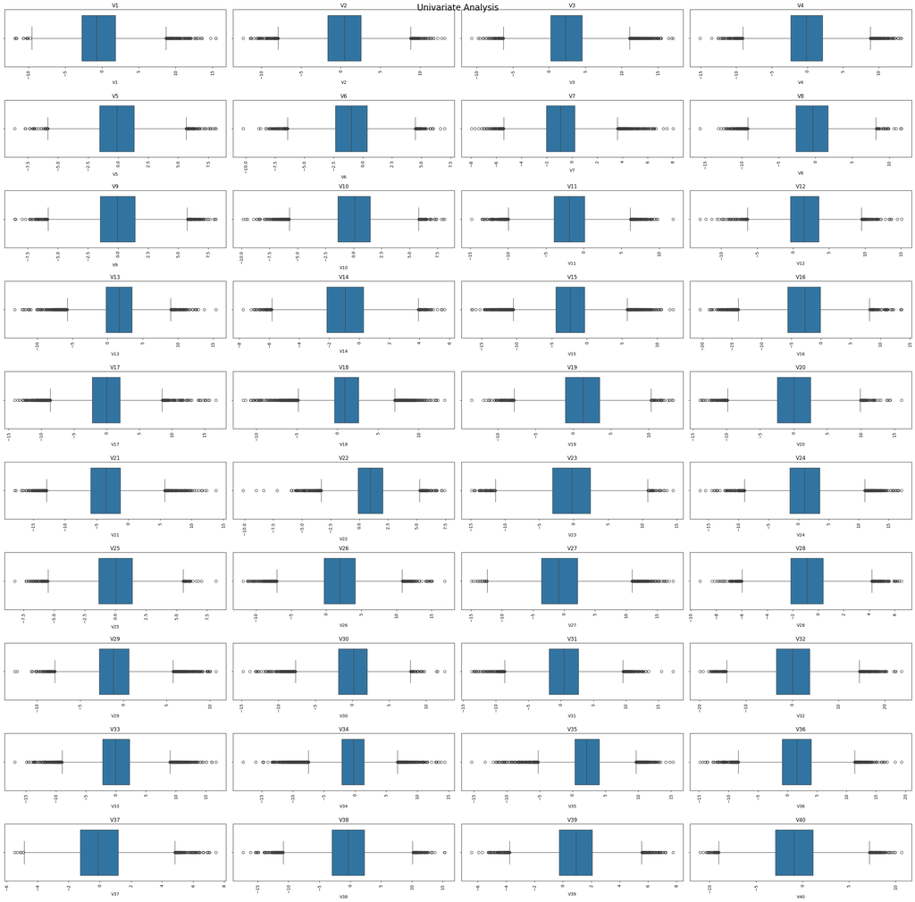

```python
#Boxplot of all numerical features
plt.figure(figsize=(30,30))
plt.suptitle('Univariate Analysis',fontsize=20)
for i, feature in enumerate(numerical):
    plt.subplot(10,4,i+1)
    sns.boxplot(data_train,x=feature)
    plt.title(feature)
    plt.xticks(rotation=90)
plt.tight_layout()
plt.show()
```

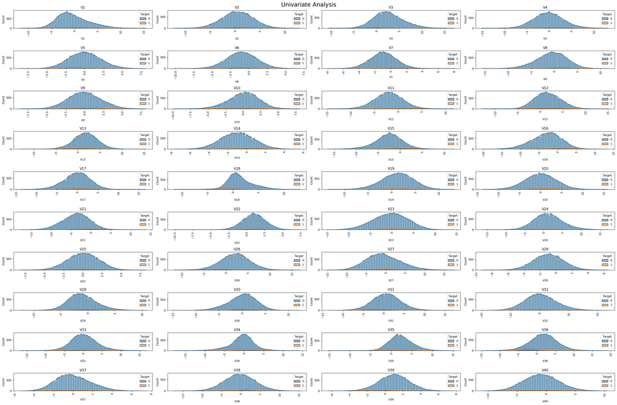

```python
plt.figure(figsize=(30,20))
plt.suptitle('Univariate Analysis',fontsize=20)
for i, feature in enumerate(numerical):
    plt.subplot(10,4,i+1)
    sns.histplot(data_train,x=feature,hue='Target', kde=True)
    plt.title(feature)
    plt.xticks(rotation=90)
plt.tight_layout()
plt.show()
```

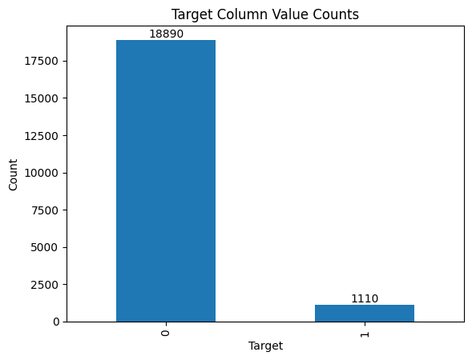

```python
#Getting the value counts of 0 and 1 for Target column and plotting this
data_train["Target"].value_counts().plot(kind="bar")
plt.xlabel("Target")
plt.ylabel("Count")
plt.title("Target Column Value Counts")
#plt to show the values of the bars
for i, v in enumerate(data_train["Target"].value_counts()):
    plt.text(i, v, str(v), ha='center', va='bottom')
plt.show()
```

#### Observations

Based on the univariate analysis of the numerical and categorical features, here are some key observations:

Univariate Analysis of Numerical Features (V1-V40):

- Boxplots: Many numerical features exhibit a wide spread and numerous outliers, indicating variability and the presence of extreme values in the data.
- Histograms: For most features, the distributions for Target '0' (No failure) and Target '1' (failure) show significant overlap. While some features might have subtle differences in their distributions between the two classes, no clear separation is immediately apparent, suggesting that individual features alone may not strongly distinguish between failure and non-failure.
- Bar plot of Target (Categorical) variable: Target Variable Distribution: There are 18,890 instances of 'No failure' (Target = 0) and 1,110 instances of 'failure' (Target = 1) in the training dataset. This confirms the significant class imbalance, where 'failure' cases constitute only about 5.5% of the data.

These observations provide initial insights into potential drivers of the failure detection, which will be further explored in bivariate analysis and model predictions and analysis.

### Bivariate Analysis

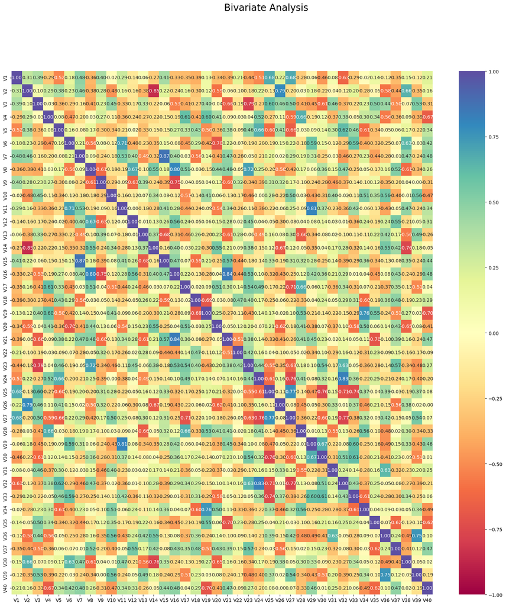

```python
plt.figure(figsize=(20,20))
plt.suptitle('Bivariate Analysis',fontsize=20)
sns.heatmap(data_train[numerical].corr(),annot=True,vmin=-1,vmax=1, fmt='.2f',cmap='Spectral')
plt.show()
```

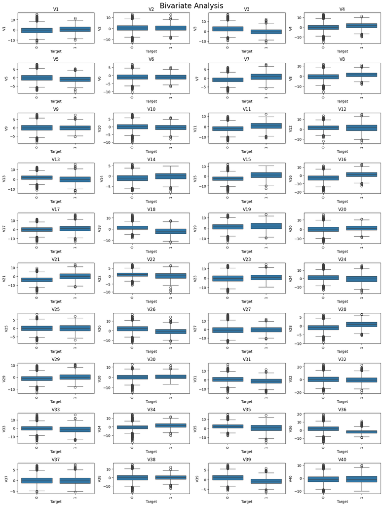

```python
plt.figure(figsize=(15,20))
plt.suptitle('Bivariate Analysis',fontsize=20)
for i, feature in enumerate(numerical):
    plt.subplot(10,4,i+1)
    sns.boxplot(data_train,y=feature,x='Target')
    plt.title(feature)
    plt.xticks(rotation=90)
plt.tight_layout()
plt.show()
```

```python
#Creating a pair plot of all variables
#plt.figure(figsize=(30,30))
#sns.pairplot(data_train,hue='Target')
#plt.show()
```

## Data Pre-processing

### Encoding of Data

#### Please Note

- The Target column is categorical with only 0 and 1 as values. Hence it doesn't require encoding. Converting it back into int column for neural network model building.
- No other categorical columns exist.

```python
#Converting Target variable back to int column
data_train["Target"]=data_train["Target"].astype("int")
data_test["Target"]=data_test["Target"].astype("int")
data_train.info()
```

```
<class 'pandas.core.frame.DataFrame'>
RangeIndex: 20000 entries, 0 to 19999
Data columns (total 41 columns):
 #   Column  Non-Null Count  Dtype
---  ------  --------------  -----
 0   V1      19982 non-null  float64
 1   V2      19982 non-null  float64
 2   V3      20000 non-null  float64
 3   V4      20000 non-null  float64
 4   V5      20000 non-null  float64
 5   V6      20000 non-null  float64
 6   V7      20000 non-null  float64
 7   V8      20000 non-null  float64
 8   V9      20000 non-null  float64
 9   V10     20000 non-null  float64
```

[output cut: 33 more lines]

### Splitting the data before building the model

Splitting the Data into Training, Validation sets.

```python
# Separating the independent and dependent variables
X_train = data_train.drop(["Target"], axis=1)
y_train = data_train["Target"]

X_test = data_test.drop(["Target"], axis=1)
y_test = data_test["Target"]

# Splitting data into training and validation sets:

# We'll split training data into 2 parts, say validation and training
X_train, X_val, y_train, y_val = train_test_split(
    X_train, y_train, test_size=1/5, random_state=1, stratify=y_train
)


#Printing the shape of the dataset.
print(X_train.shape)
print(y_train.shape)
print(X_val.shape)
print(y_val.shape)
print(X_test.shape)
print(y_test.shape)
```

```
(16000, 40)
(16000,)
(4000, 40)
(4000,)
(5000, 40)
(5000,)
```

### Creating Dummy Variables, Imputation of Missing Variables, Etc AFTER Splitting Training, Validation and Test DataSets to avoid Data Leak

#### Scaling the Data

```python
# Normalizing the data in each numerical column in X_train, X_val and X_test in a loop
for col in numerical:
    min_val = X_train[col].min()
    max_val = X_train[col].max()

    if (max_val - min_val) == 0:
        # If max and min are the same, all values are identical. Set them to a constant after scaling (e.g., 0.5)
        X_train[col] = 0.5
        X_val[col] = 0.5
        X_test[col] = 0.5
    else:
        # Apply Min-Max scaling
        X_train[col] = (X_train[col] - min_val) / (max_val - min_val)
        X_val[col] = (X_val[col] - min_val) / (max_val - min_val)
        X_test[col] = (X_test[col] - min_val) / (max_val - min_val)

print(X_train.head())
print(X_val.head())
print(X_test.head())

# Add a check to confirm no NaNs after scaling
print("\nNaNs in X_train after scaling:", X_train.isna().sum().sum())
print("NaNs in X_val after scaling:", X_val.isna().sum().sum())
print("NaNs in X_test after scaling:", X_test.isna().sum().sum())
```

```
             V1        V2        V3        V4        V5        V6        V7  \
5949   0.309409  0.690239  0.408153  0.580968  0.799225  0.678514  0.428434
18977  0.452786  0.432614  0.521885  0.532289  0.403685  0.465816  0.461561
7985   0.247533  0.377753  0.372641  0.526609  0.614310  0.515722  0.296149
18818  0.605683  0.520096  0.517184  0.504051  0.383600  0.604052  0.445977
48     0.508957  0.484243  0.440473  0.521122  0.529807  0.488437  0.474599

             V8        V9       V10  ...       V31       V32       V33  \
5949   0.543245  0.345198  0.497605  ...  0.631118  0.728202  0.861609
18977  0.565588  0.497846  0.653017  ...  0.467502  0.425087  0.449959
7985   0.560882  0.446297  0.658862  ...  0.456764  0.648913  0.551922
18818  0.492766  0.521944  0.551859  ...  0.454144  0.423774  0.596701
48     0.639565  0.420015  0.578428  ...  0.532670  0.538136  0.475462

            V34       V35       V36       V37       V38       V39       V40
5949   0.350814  0.638861  0.357395  0.184281  0.663830  0.344500  0.512571
18977  0.647579  0.566477  0.527152  0.401651  0.478943  0.611853  0.352789
7985   0.518000  0.557009  0.569483  0.482161  0.494222  0.627474  0.330235
18818  0.508777  0.708428  0.391330  0.306197  0.565652  0.410729  0.466242
48     0.522728  0.579739  0.490886  0.403555  0.485999  0.425721  0.516446

[5 rows x 40 columns]
             V1        V2        V3        V4        V5        V6        V7  \
10019  0.739243  0.587221  0.805397  0.422375  0.372168  0.488318  0.513487
12223  0.639254  0.570539  0.425892  0.655209  0.368972  0.568855  0.408499
1621   0.314473  0.446096  0.300795  0.450059  0.599069  0.712019  0.417193
17851  0.291562  0.548586  0.637405  0.695289  0.578146  0.374603  0.354745
9803   0.487668  0.416658  0.304448  0.520934  0.485350  0.527650  0.552117

             V8        V9       V10  ...       V31       V32       V33  \
10019  0.414701  0.625553  0.639922  ...  0.630887  0.225557  0.380003
12223  0.463255  0.759613  0.437028  ...  0.317217  0.461636  0.559227
1621   0.486868  0.419699  0.603733  ...  0.396477  0.515472  0.618907
17851  0.508829  0.539652  0.627084  ...  0.495460  0.486941  0.431997
9803   0.719291  0.515512  0.466060  ...  0.440795  0.420094  0.390216

            V34       V35       V36       V37       V38       V39       V40
10019  0.580473  0.590005  0.617338  0.271119  0.499894  0.684196  0.497862
12223  0.486859  0.688404  0.243828  0.272853  0.517811  0.294341  0.345446
1621   0.512921  0.479674  0.477176  0.500678  0.657012  0.574879  0.485379
```

[output cut: 15 more lines]

```
3  0.582618  0.592734  0.581685  ...  0.561621  0.537683  0.411549  0.547281
4  0.608061  0.628347  0.385286  ...  0.320364  0.497598  0.458362  0.487223

        V35       V36       V37       V38       V39       V40
0  0.485670  0.550158  0.551726  0.210123  0.485503  0.441714
1  0.537562  0.447178  0.398861  0.688915  0.574672  0.439875
2  0.487253  0.593870  0.543371  0.478276  0.580838  0.585827
3  0.498954  0.516719  0.328422  0.427457  0.517290  0.395469
4  0.632538  0.232416  0.373290  0.523467  0.181753  0.483723

[5 rows x 40 columns]

NaNs in X_train after scaling: 30
NaNs in X_val after scaling: 6
NaNs in X_test after scaling: 11
```

#### Imputing Missing Values

```python
v1_train_median=X_train["V1"].median()
v2_train_median=X_train["V2"].median()

#Imputing the median value of V1 and V2 from the Training Data into the training, validation and test data for missing values
X_train["V1"].fillna(v1_train_median , inplace=True)
X_val["V1"].fillna(v1_train_median , inplace=True)
X_test["V1"].fillna(v1_train_median , inplace=True)

X_train["V2"].fillna(v2_train_median, inplace=True)
X_val["V2"].fillna(v2_train_median, inplace=True)
X_test["V2"].fillna(v2_train_median, inplace=True)

#checking for null values in X_train, X_val and X_test
if(X_train.isna().sum().sum()==0 and X_val.isna().sum().sum()==0 and X_test.isna().sum().sum()==0):
  print("No null values in X_train, X_val and X_test")
```

```
No null values in X_train, X_val and X_test
```

```python
print(X_train.shape[0], "train samples")
print(X_val.shape[0], "validation samples")
print(X_test.shape[0], "test samples")
```

```
16000 train samples
4000 validation samples
5000 test samples
```

```python
y_train.sample(5)
```

|  | Target |
| --- | --- |
| 5656 | 1 |
| 1582 | 0 |
| 15199 | 0 |
| 13839 | 0 |
| 18945 | 0 |

**dtype:** int64

#### Summarizing the above

- Data Splitting: The original training data (data_train) was divided into training (X_train, y_train) and validation (X_val, y_val) sets using a 80/20 split, with stratify=y_train to maintain the proportion of target classes. A separate test set (X_test, y_test) was also prepared from data_test. This ensures proper evaluation of model generalization.
- Data Scaling: All numerical features (V1-V40) in X_train, X_val, and X_test were normalized using Min-Max scaling. Importantly, the minimum and maximum values used for scaling were calculated only from the X_train dataset. This prevents data leakage from the validation and test sets into the training process.
- Missing Value Imputation: Missing values in columns V1 and V2 were imputed using the median values. Similar to scaling, these median values were calculated only from the X_train dataset and then applied consistently across X_train, X_val, and X_test to prevent data leakage.
- Data Leakage Prevention: Both scaling and imputation methods were carefully applied using parameters derived solely from the training data, effectively preventing data leakage and ensuring that the evaluation on validation and test sets is unbiased.
- Final Data Integrity: After imputation, it was confirmed that there are no remaining null values in X_train, X_val, or X_test.

### Utility Functions

```python
def plot(history, name):
    """
    Function to plot loss/accuracy

    history: an object which stores the metrics and losses.
    name: can be one of Loss or Accuracy
    """
    fig, ax = plt.subplots() #Creating a subplot with figure and axes.
    plt.plot(history.history[name]) #Plotting the train accuracy or train loss
    plt.plot(history.history['val_'+name]) #Plotting the validation accuracy or validation loss

    plt.title('Model ' + name.capitalize()) #Defining the title of the plot.
    plt.ylabel(name.capitalize()) #Capitalizing the first letter.
    plt.xlabel('Epoch') #Defining the label for the x-axis.
    fig.legend(['Train', 'Validation'], loc="outside right upper") #Defining the legend, loc controls the position of the legend.
```

Dataframe to store the results from all the models we build

```python
#Defining the columns of the dataframe which are nothing but the hyper parameters and the metrics.
columns = ["# hidden layers","# neurons - hidden layer","activation function - hidden layer ","# epochs","batch size","optimizer","class weights","learning rate, momentum","weight initializer","regularization","train loss","validation loss","train accuracy","validation accuracy","time (secs)"]

#Creating a pandas dataframe.
results = pd.DataFrame(columns=columns)
```

```python
results.info()
```

```
<class 'pandas.core.frame.DataFrame'>
RangeIndex: 0 entries
Data columns (total 15 columns):
 #   Column                               Non-Null Count  Dtype
---  ------                               --------------  -----
 0   # hidden layers                      0 non-null      object
 1   # neurons - hidden layer             0 non-null      object
 2   activation function - hidden layer   0 non-null      object
 3   # epochs                             0 non-null      object
 4   batch size                           0 non-null      object
 5   optimizer                            0 non-null      object
 6   class weights                        0 non-null      object
 7   learning rate, momentum              0 non-null      object
 8   weight initializer                   0 non-null      object
 9   regularization                       0 non-null      object
 10  train loss                           0 non-null      object
 11  validation loss                      0 non-null      object
 12  train accuracy                       0 non-null      object
 13  validation accuracy                  0 non-null      object
 14  time (secs)                          0 non-null      object
dtypes: object(15)
memory usage: 132.0+ bytes
```

## Model Building

### Model 0

We'll start out with a baseline model having the following configuration:

- 1 input, 1 hidden (64 nodes), 1 output layers
- relu activations for the hidden layer
- Stochastic Gradient Descent (SGD)

```python
batch_size = 1000
epochs = 30
num_classes=1 #Output is the Target variable alone
```

```python
# clears the current Keras session, resetting all layers and models previously created, freeing up memory and resources.
tf.keras.backend.clear_session()
```

```python
#Initializing the neural network

bce_logits_loss = tf.keras.losses.BinaryCrossentropy(from_logits=True)
optimizer = keras.optimizers.SGD()    # defining SGD as the optimizer to be used

model_1 = Sequential()
model_1.add(Dense(64,activation="relu",input_dim = X_train.shape[1]))
model_1.add(Dense(num_classes)) # Removed activation='sigmoid' because from_logits=True is used in the loss function
```

```python
model_1.summary()
```

```
Model: "sequential"
```

```
┏━━━━━━━━━━━━━━━━━━━━━━━━━━━━━━━━━┳━━━━━━━━━━━━━━━━━━━━━━━━┳━━━━━━━━━━━━━━━┓
┃ Layer (type)                    ┃ Output Shape           ┃       Param # ┃
┡━━━━━━━━━━━━━━━━━━━━━━━━━━━━━━━━━╇━━━━━━━━━━━━━━━━━━━━━━━━╇━━━━━━━━━━━━━━━┩
│ dense (Dense)                   │ (None, 64)             │         2,624 │
├─────────────────────────────────┼────────────────────────┼───────────────┤
│ dense_1 (Dense)                 │ (None, 1)              │            65 │
└─────────────────────────────────┴────────────────────────┴───────────────┘
```

```
 Total params: 2,689 (10.50 KB)
```

```
 Trainable params: 2,689 (10.50 KB)
```

```
 Non-trainable params: 0 (0.00 B)
```

```python
model_1.compile(loss=bce_logits_loss, optimizer=optimizer, metrics=["accuracy"])
```

```python
start = time.time()
history = model_1.fit(X_train, y_train, validation_data=(X_val,y_val) , batch_size=batch_size, epochs=epochs)
end=time.time()
```

```
16/16 ━━━━━━━━━━━━━━━━━━━━ 1s 19ms/step - accuracy: 0.9450 - loss: 0.4974 - val_accuracy: 0.9445 - val_loss: 0.3442
16/16 ━━━━━━━━━━━━━━━━━━━━ 0s 8ms/step - accuracy: 0.9455 - loss: 0.3200 - val_accuracy: 0.9445 - val_loss: 0.2731
16/16 ━━━━━━━━━━━━━━━━━━━━ 0s 8ms/step - accuracy: 0.9442 - loss: 0.2645 - val_accuracy: 0.9445 - val_loss: 0.2444
16/16 ━━━━━━━━━━━━━━━━━━━━ 0s 8ms/step - accuracy: 0.9422 - loss: 0.2449 - val_accuracy: 0.9445 - val_loss: 0.2308
16/16 ━━━━━━━━━━━━━━━━━━━━ 0s 9ms/step - accuracy: 0.9453 - loss: 0.2272 - val_accuracy: 0.9445 - val_loss: 0.2238
16/16 ━━━━━━━━━━━━━━━━━━━━ 0s 8ms/step - accuracy: 0.9425 - loss: 0.2274 - val_accuracy: 0.9445 - val_loss: 0.2198
16/16 ━━━━━━━━━━━━━━━━━━━━ 0s 12ms/step - accuracy: 0.9449 - loss: 0.2183 - val_accuracy: 0.9445 - val_loss: 0.2174
16/16 ━━━━━━━━━━━━━━━━━━━━ 0s 12ms/step - accuracy: 0.9447 - loss: 0.2164 - val_accuracy: 0.9445 - val_loss: 0.2159
16/16 ━━━━━━━━━━━━━━━━━━━━ 0s 13ms/step - accuracy: 0.9448 - loss: 0.2153 - val_accuracy: 0.9445 - val_loss: 0.2149
16/16 ━━━━━━━━━━━━━━━━━━━━ 0s 14ms/step - accuracy: 0.9444 - loss: 0.2150 - val_accuracy: 0.9445 - val_loss: 0.2142
16/16 ━━━━━━━━━━━━━━━━━━━━ 0s 13ms/step - accuracy: 0.9448 - loss: 0.2132 - val_accuracy: 0.9445 - val_loss: 0.2137
16/16 ━━━━━━━━━━━━━━━━━━━━ 0s 14ms/step - accuracy: 0.9463 - loss: 0.2093 - val_accuracy: 0.9445 - val_loss: 0.2133
16/16 ━━━━━━━━━━━━━━━━━━━━ 0s 12ms/step - accuracy: 0.9436 - loss: 0.2160 - val_accuracy: 0.9445 - val_loss: 0.2130
16/16 ━━━━━━━━━━━━━━━━━━━━ 0s 13ms/step - accuracy: 0.9451 - loss: 0.2121 - val_accuracy: 0.9445 - val_loss: 0.2127
16/16 ━━━━━━━━━━━━━━━━━━━━ 0s 13ms/step - accuracy: 0.9435 - loss: 0.2158 - val_accuracy: 0.9445 - val_loss: 0.2124
16/16 ━━━━━━━━━━━━━━━━━━━━ 0s 11ms/step - accuracy: 0.9463 - loss: 0.2076 - val_accuracy: 0.9445 - val_loss: 0.2122
16/16 ━━━━━━━━━━━━━━━━━━━━ 0s 11ms/step - accuracy: 0.9433 - loss: 0.2158 - val_accuracy: 0.9445 - val_loss: 0.2120
16/16 ━━━━━━━━━━━━━━━━━━━━ 0s 15ms/step - accuracy: 0.9433 - loss: 0.2155 - val_accuracy: 0.9445 - val_loss: 0.2118
16/16 ━━━━━━━━━━━━━━━━━━━━ 0s 14ms/step - accuracy: 0.9426 - loss: 0.2173 - val_accuracy: 0.9445 - val_loss: 0.2116
16/16 ━━━━━━━━━━━━━━━━━━━━ 0s 13ms/step - accuracy: 0.9450 - loss: 0.2101 - val_accuracy: 0.9445 - val_loss: 0.2114
16/16 ━━━━━━━━━━━━━━━━━━━━ 0s 8ms/step - accuracy: 0.9434 - loss: 0.2147 - val_accuracy: 0.9445 - val_loss: 0.2112
16/16 ━━━━━━━━━━━━━━━━━━━━ 0s 7ms/step - accuracy: 0.9454 - loss: 0.2090 - val_accuracy: 0.9445 - val_loss: 0.2110
16/16 ━━━━━━━━━━━━━━━━━━━━ 0s 9ms/step - accuracy: 0.9432 - loss: 0.2153 - val_accuracy: 0.9445 - val_loss: 0.2108
16/16 ━━━━━━━━━━━━━━━━━━━━ 0s 8ms/step - accuracy: 0.9455 - loss: 0.2086 - val_accuracy: 0.9445 - val_loss: 0.2107
16/16 ━━━━━━━━━━━━━━━━━━━━ 0s 9ms/step - accuracy: 0.9447 - loss: 0.2103 - val_accuracy: 0.9445 - val_loss: 0.2105
16/16 ━━━━━━━━━━━━━━━━━━━━ 0s 10ms/step - accuracy: 0.9419 - loss: 0.2180 - val_accuracy: 0.9445 - val_loss: 0.2103
16/16 ━━━━━━━━━━━━━━━━━━━━ 0s 9ms/step - accuracy: 0.9459 - loss: 0.2068 - val_accuracy: 0.9445 - val_loss: 0.2101
16/16 ━━━━━━━━━━━━━━━━━━━━ 0s 10ms/step - accuracy: 0.9478 - loss: 0.2016 - val_accuracy: 0.9445 - val_loss: 0.2100
16/16 ━━━━━━━━━━━━━━━━━━━━ 0s 10ms/step - accuracy: 0.9451 - loss: 0.2087 - val_accuracy: 0.9445 - val_loss: 0.2098
16/16 ━━━━━━━━━━━━━━━━━━━━ 0s 10ms/step - accuracy: 0.9450 - loss: 0.2088 - val_accuracy: 0.9445 - val_loss: 0.2096
```

```python
print("Time taken in seconds ",end-start)
```

```
Time taken in seconds  6.945760726928711
```

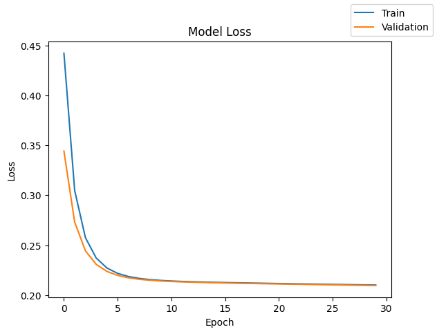

```python
plot(history,'loss')
```

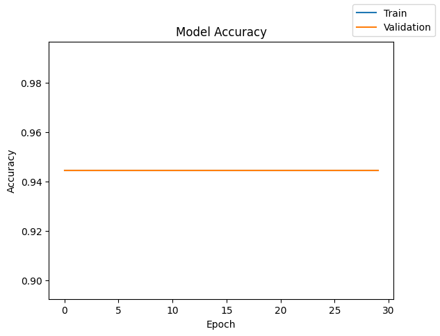

```python
plot(history,'accuracy')
```

```python
#Add an entry to results

results.loc[0] = [1,[64],["relu"],30,1000,"sgd","-","-","-","-",history.history["loss"][-1],history.history["val_loss"][-1],history.history["accuracy"][-1],history.history["val_accuracy"][-1],round(end-start,2)]
```

```python
results
```

|  | # hidden layers | # neurons - hidden layer | activation function - hidden layer | # epochs | batch size | optimizer | class weights | learning rate, momentum | weight initializer | regularization | train loss | validation loss | train accuracy | validation accuracy | time (secs) |
| --- | --- | --- | --- | --- | --- | --- | --- | --- | --- | --- | --- | --- | --- | --- | --- |
| 0 | 1 | [64] | [relu] | 30 | 1000 | sgd | - | - | - | - | 0.210152 | 0.209642 | 0.9445 | 0.9445 | 6.95 |

### Observations

Here are the observations and notes for Model 0:

Model Architecture: This baseline model consists of:

1 input layer (matching the 40 features). 1 hidden layer with 64 neurons and relu activation. 1 output layer with 1 neuron and no activation (logits), suitable for BinaryCrossentropy(from_logits=True).

Training Configuration:

Epochs: 30 Batch Size: 1000 Optimizer: Stochastic Gradient Descent (SGD) Loss Function: BinaryCrossentropy(from_logits=True)

Performance Metrics (after 30 epochs):

Training Loss: ~0.210 Validation Loss: ~0.210 Training Accuracy: ~0.9445 Validation Accuracy: ~0.9445 Time Taken: ~6.95 seconds

**Observations**: The training and validation accuracy quickly stabilized around 0.9445. Given the class imbalance observed earlier (approximately 94.45% 'No Failure' cases), this suggests that the model is primarily predicting the majority class. It is not effectively learning to distinguish the minority 'failure' class. This is common with imbalanced datasets and indicates that further techniques (like class weighting, different architectures, or data resampling) will be needed to improve its ability to detect failures.

```python
from sklearn.utils import class_weight
```

### Model 1

We'll keep the same model but with class weights (1:5) having the following configuration:

1 input, 1 hidden (64 nodes), 1 output layers relu activations for the hidden layer Stochastic Gradient Descent (SGD)

```python
batch_size = 1000
epochs = 30
num_classes=1 #Output is the Target variable alone
```

```python
# clears the current Keras session, resetting all layers and models previously created, freeing up memory and resources.
tf.keras.backend.clear_session()
```

```python
#Initializing the neural network

bce_logits_loss = tf.keras.losses.BinaryCrossentropy(from_logits=True)
optimizer = keras.optimizers.SGD()    # defining SGD as the optimizer to be used

model_1 = Sequential()
model_1.add(Dense(64,activation="relu",input_dim = X_train.shape[1]))
model_1.add(Dense(num_classes)) # Removed activation='sigmoid' because from_logits=True is used in the loss function
```

```python
model_1.summary()
```

```
Model: "sequential"
```

```
┏━━━━━━━━━━━━━━━━━━━━━━━━━━━━━━━━━┳━━━━━━━━━━━━━━━━━━━━━━━━┳━━━━━━━━━━━━━━━┓
┃ Layer (type)                    ┃ Output Shape           ┃       Param # ┃
┡━━━━━━━━━━━━━━━━━━━━━━━━━━━━━━━━━╇━━━━━━━━━━━━━━━━━━━━━━━━╇━━━━━━━━━━━━━━━┩
│ dense (Dense)                   │ (None, 64)             │         2,624 │
├─────────────────────────────────┼────────────────────────┼───────────────┤
│ dense_1 (Dense)                 │ (None, 1)              │            65 │
└─────────────────────────────────┴────────────────────────┴───────────────┘
```

```
 Total params: 2,689 (10.50 KB)
```

```
 Trainable params: 2,689 (10.50 KB)
```

```
 Non-trainable params: 0 (0.00 B)
```

```python
model_1.compile(loss=bce_logits_loss, optimizer=optimizer, metrics=["accuracy"])
```

```python
class_weights = {0: 1.0, 1: 5.0}
start = time.time()
history = model_1.fit(X_train, y_train, validation_data=(X_val,y_val) , class_weight=class_weights, batch_size=batch_size, epochs=epochs)
end=time.time()
```

```
16/16 ━━━━━━━━━━━━━━━━━━━━ 1s 24ms/step - accuracy: 0.9401 - loss: 0.8381 - val_accuracy: 0.9445 - val_loss: 0.4785
16/16 ━━━━━━━━━━━━━━━━━━━━ 0s 10ms/step - accuracy: 0.9459 - loss: 0.6799 - val_accuracy: 0.9445 - val_loss: 0.3922
16/16 ━━━━━━━━━━━━━━━━━━━━ 0s 14ms/step - accuracy: 0.9455 - loss: 0.6504 - val_accuracy: 0.9445 - val_loss: 0.3564
16/16 ━━━━━━━━━━━━━━━━━━━━ 0s 13ms/step - accuracy: 0.9437 - loss: 0.6504 - val_accuracy: 0.9445 - val_loss: 0.3385
16/16 ━━━━━━━━━━━━━━━━━━━━ 0s 14ms/step - accuracy: 0.9448 - loss: 0.6384 - val_accuracy: 0.9445 - val_loss: 0.3287
16/16 ━━━━━━━━━━━━━━━━━━━━ 0s 13ms/step - accuracy: 0.9470 - loss: 0.6195 - val_accuracy: 0.9445 - val_loss: 0.3239
16/16 ━━━━━━━━━━━━━━━━━━━━ 0s 13ms/step - accuracy: 0.9440 - loss: 0.6351 - val_accuracy: 0.9445 - val_loss: 0.3202
16/16 ━━━━━━━━━━━━━━━━━━━━ 0s 16ms/step - accuracy: 0.9465 - loss: 0.6163 - val_accuracy: 0.9445 - val_loss: 0.3184
16/16 ━━━━━━━━━━━━━━━━━━━━ 0s 12ms/step - accuracy: 0.9450 - loss: 0.6226 - val_accuracy: 0.9445 - val_loss: 0.3163
16/16 ━━━━━━━━━━━━━━━━━━━━ 0s 13ms/step - accuracy: 0.9405 - loss: 0.6501 - val_accuracy: 0.9445 - val_loss: 0.3132
16/16 ━━━━━━━━━━━━━━━━━━━━ 0s 12ms/step - accuracy: 0.9446 - loss: 0.6182 - val_accuracy: 0.9445 - val_loss: 0.3122
16/16 ━━━━━━━━━━━━━━━━━━━━ 0s 14ms/step - accuracy: 0.9428 - loss: 0.6269 - val_accuracy: 0.9445 - val_loss: 0.3105
16/16 ━━━━━━━━━━━━━━━━━━━━ 0s 13ms/step - accuracy: 0.9451 - loss: 0.6081 - val_accuracy: 0.9445 - val_loss: 0.3095
16/16 ━━━━━━━━━━━━━━━━━━━━ 0s 14ms/step - accuracy: 0.9452 - loss: 0.6054 - val_accuracy: 0.9445 - val_loss: 0.3088
16/16 ━━━━━━━━━━━━━━━━━━━━ 0s 14ms/step - accuracy: 0.9440 - loss: 0.6095 - val_accuracy: 0.9445 - val_loss: 0.3068
16/16 ━━━━━━━━━━━━━━━━━━━━ 0s 14ms/step - accuracy: 0.9442 - loss: 0.6071 - val_accuracy: 0.9445 - val_loss: 0.3059
16/16 ━━━━━━━━━━━━━━━━━━━━ 0s 9ms/step - accuracy: 0.9457 - loss: 0.5934 - val_accuracy: 0.9445 - val_loss: 0.3051
16/16 ━━━━━━━━━━━━━━━━━━━━ 0s 9ms/step - accuracy: 0.9471 - loss: 0.5822 - val_accuracy: 0.9445 - val_loss: 0.3047
16/16 ━━━━━━━━━━━━━━━━━━━━ 0s 8ms/step - accuracy: 0.9454 - loss: 0.5902 - val_accuracy: 0.9445 - val_loss: 0.3029
16/16 ━━━━━━━━━━━━━━━━━━━━ 0s 8ms/step - accuracy: 0.9440 - loss: 0.5949 - val_accuracy: 0.9445 - val_loss: 0.3014
16/16 ━━━━━━━━━━━━━━━━━━━━ 0s 8ms/step - accuracy: 0.9455 - loss: 0.5832 - val_accuracy: 0.9445 - val_loss: 0.3005
16/16 ━━━━━━━━━━━━━━━━━━━━ 0s 9ms/step - accuracy: 0.9475 - loss: 0.5713 - val_accuracy: 0.9445 - val_loss: 0.3011
16/16 ━━━━━━━━━━━━━━━━━━━━ 0s 9ms/step - accuracy: 0.9458 - loss: 0.5809 - val_accuracy: 0.9445 - val_loss: 0.2995
16/16 ━━━━━━━━━━━━━━━━━━━━ 0s 9ms/step - accuracy: 0.9447 - loss: 0.5827 - val_accuracy: 0.9445 - val_loss: 0.2976
16/16 ━━━━━━━━━━━━━━━━━━━━ 0s 8ms/step - accuracy: 0.9447 - loss: 0.5805 - val_accuracy: 0.9445 - val_loss: 0.2963
16/16 ━━━━━━━━━━━━━━━━━━━━ 0s 8ms/step - accuracy: 0.9447 - loss: 0.5762 - val_accuracy: 0.9445 - val_loss: 0.2955
16/16 ━━━━━━━━━━━━━━━━━━━━ 0s 8ms/step - accuracy: 0.9444 - loss: 0.5748 - val_accuracy: 0.9445 - val_loss: 0.2936
16/16 ━━━━━━━━━━━━━━━━━━━━ 0s 8ms/step - accuracy: 0.9443 - loss: 0.5764 - val_accuracy: 0.9445 - val_loss: 0.2922
16/16 ━━━━━━━━━━━━━━━━━━━━ 0s 9ms/step - accuracy: 0.9452 - loss: 0.5668 - val_accuracy: 0.9445 - val_loss: 0.2915
16/16 ━━━━━━━━━━━━━━━━━━━━ 0s 8ms/step - accuracy: 0.9438 - loss: 0.5717 - val_accuracy: 0.9445 - val_loss: 0.2893
```

```python
print("Time taken in seconds ",end-start)
```

```
Time taken in seconds  7.64680552482605
```

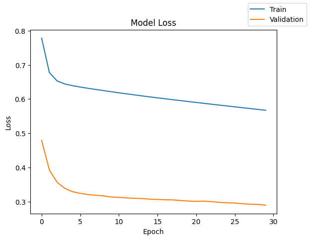

```python
plot(history,'loss')
```

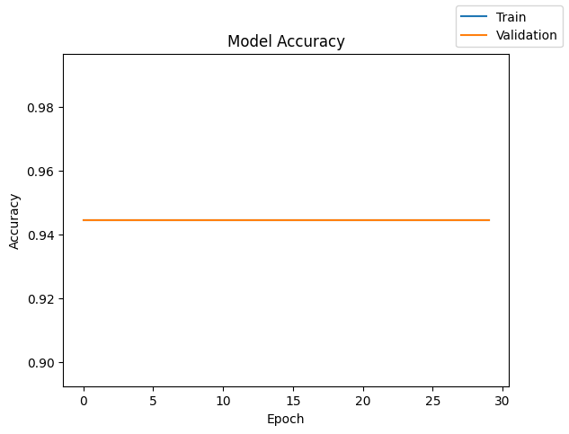

```python
plot(history,'accuracy')
```

```python
#Add an entry to results

results.loc[1] = [1,64,"relu",30,1000,"sgd","1:5","-","-","-",history.history["loss"][-1],history.history["val_loss"][-1],history.history["accuracy"][-1],history.history["val_accuracy"][-1],round(end-start,2)]
```

```python
results
```

|  | # hidden layers | # neurons - hidden layer | activation function - hidden layer | # epochs | batch size | optimizer | class weights | learning rate, momentum | weight initializer | regularization | train loss | validation loss | train accuracy | validation accuracy | time (secs) |
| --- | --- | --- | --- | --- | --- | --- | --- | --- | --- | --- | --- | --- | --- | --- | --- |
| 0 | 1 | [64] | [relu] | 30 | 1000 | sgd | - | - | - | - | 0.210152 | 0.209642 | 0.9445 | 0.9445 | 6.95 |
| 1 | 1 | 64 | relu | 30 | 1000 | sgd | 1:5 | - | - | - | 0.567296 | 0.289252 | 0.9445 | 0.9445 | 7.65 |

### Observations

Observations and notes for Model 1:

Model Architecture: This model is identical to Model 0, consisting of:

1 input layer (matching the 40 features). 1 hidden layer with 64 neurons and relu activation. 1 output layer with 1 neuron and no activation (logits), suitable for BinaryCrossentropy(from_logits=True). Training Configuration:

Epochs: 30 Batch Size: 1000 Optimizer: Stochastic Gradient Descent (SGD) Loss Function: BinaryCrossentropy(from_logits=True) Class Weights: {0: 1.0, 1: 5.0} (applied to address class imbalance) Performance Metrics (after 30 epochs):

Training Loss: ~0.567 Validation Loss: ~0.289 Training Accuracy: ~0.9445 Validation Accuracy: ~0.9445 Time Taken: ~7.65 seconds

**Observations**: After applying class weights to penalize misclassifications of the minority class ('failure') more heavily, the overall accuracy for both training and validation sets remained at approximately 0.9445, similar to Model 0. This suggests that while the loss values changed significantly (training loss increased, validation loss slightly increased), the basic accuracy metric is still dominated by the correct prediction of the majority class. The class weights have influenced the model's learning process, as evidenced by the higher training loss, but a simple accuracy metric does not fully capture the improvement (or lack thereof) in predicting the minority class. Further evaluation with metrics like recall, precision, or F1-score specifically for the positive class would be necessary to truly understand the impact of class weighting on detecting failures.

### Model 2

We'll keep the same model but with class weights (0.5:9) having the following configuration:

1 input, 1 hidden (64 nodes), 1 output layers relu activations for the hidden layer Stochastic Gradient Descent (SGD)

```python
batch_size = 1000
epochs = 30
num_classes=1 #Output is the Target variable alone
```

```python
# clears the current Keras session, resetting all layers and models previously created, freeing up memory and resources.
tf.keras.backend.clear_session()
```

```python
#Initializing the neural network

bce_logits_loss = tf.keras.losses.BinaryCrossentropy(from_logits=True)
optimizer = keras.optimizers.SGD()    # defining SGD as the optimizer to be used

model_1 = Sequential()
model_1.add(Dense(64,activation="relu",input_dim = X_train.shape[1]))
model_1.add(Dense(num_classes)) # Removed activation='sigmoid' because from_logits=True is used in the loss function
```

```python
model_1.summary()
```

```
Model: "sequential"
```

```
┏━━━━━━━━━━━━━━━━━━━━━━━━━━━━━━━━━┳━━━━━━━━━━━━━━━━━━━━━━━━┳━━━━━━━━━━━━━━━┓
┃ Layer (type)                    ┃ Output Shape           ┃       Param # ┃
┡━━━━━━━━━━━━━━━━━━━━━━━━━━━━━━━━━╇━━━━━━━━━━━━━━━━━━━━━━━━╇━━━━━━━━━━━━━━━┩
│ dense (Dense)                   │ (None, 64)             │         2,624 │
├─────────────────────────────────┼────────────────────────┼───────────────┤
│ dense_1 (Dense)                 │ (None, 1)              │            65 │
└─────────────────────────────────┴────────────────────────┴───────────────┘
```

```
 Total params: 2,689 (10.50 KB)
```

```
 Trainable params: 2,689 (10.50 KB)
```

```
 Non-trainable params: 0 (0.00 B)
```

```python
model_1.compile(loss=bce_logits_loss, optimizer=optimizer, metrics=["accuracy"])
```

```python
class_weights = {0: 0.5, 1: 9.0}
start = time.time()
history = model_1.fit(X_train, y_train, validation_data=(X_val,y_val) , class_weight=class_weights, batch_size=batch_size, epochs=epochs)
end=time.time()
```

```
16/16 ━━━━━━━━━━━━━━━━━━━━ 1s 22ms/step - accuracy: 0.9422 - loss: 0.6935 - val_accuracy: 0.9445 - val_loss: 0.7575
16/16 ━━━━━━━━━━━━━━━━━━━━ 0s 9ms/step - accuracy: 0.9445 - loss: 0.6767 - val_accuracy: 0.9445 - val_loss: 0.7373
16/16 ━━━━━━━━━━━━━━━━━━━━ 0s 9ms/step - accuracy: 0.9462 - loss: 0.6623 - val_accuracy: 0.9445 - val_loss: 0.7251
16/16 ━━━━━━━━━━━━━━━━━━━━ 0s 7ms/step - accuracy: 0.9471 - loss: 0.6517 - val_accuracy: 0.9445 - val_loss: 0.7151
16/16 ━━━━━━━━━━━━━━━━━━━━ 0s 7ms/step - accuracy: 0.9461 - loss: 0.6539 - val_accuracy: 0.9445 - val_loss: 0.7083
16/16 ━━━━━━━━━━━━━━━━━━━━ 0s 8ms/step - accuracy: 0.9418 - loss: 0.6726 - val_accuracy: 0.9445 - val_loss: 0.7010
16/16 ━━━━━━━━━━━━━━━━━━━━ 0s 7ms/step - accuracy: 0.9468 - loss: 0.6402 - val_accuracy: 0.9448 - val_loss: 0.6985
16/16 ━━━━━━━━━━━━━━━━━━━━ 0s 8ms/step - accuracy: 0.9436 - loss: 0.6549 - val_accuracy: 0.9450 - val_loss: 0.6937
16/16 ━━━━━━━━━━━━━━━━━━━━ 0s 9ms/step - accuracy: 0.9431 - loss: 0.6558 - val_accuracy: 0.9455 - val_loss: 0.6891
16/16 ━━━━━━━━━━━━━━━━━━━━ 0s 8ms/step - accuracy: 0.9450 - loss: 0.6427 - val_accuracy: 0.9455 - val_loss: 0.6863
16/16 ━━━━━━━━━━━━━━━━━━━━ 0s 7ms/step - accuracy: 0.9453 - loss: 0.6408 - val_accuracy: 0.9457 - val_loss: 0.6836
16/16 ━━━━━━━━━━━━━━━━━━━━ 0s 7ms/step - accuracy: 0.9481 - loss: 0.6234 - val_accuracy: 0.9465 - val_loss: 0.6833
16/16 ━━━━━━━━━━━━━━━━━━━━ 0s 8ms/step - accuracy: 0.9465 - loss: 0.6316 - val_accuracy: 0.9467 - val_loss: 0.6802
16/16 ━━━━━━━━━━━━━━━━━━━━ 0s 7ms/step - accuracy: 0.9454 - loss: 0.6352 - val_accuracy: 0.9467 - val_loss: 0.6767
16/16 ━━━━━━━━━━━━━━━━━━━━ 0s 8ms/step - accuracy: 0.9476 - loss: 0.6258 - val_accuracy: 0.9475 - val_loss: 0.6725
16/16 ━━━━━━━━━━━━━━━━━━━━ 0s 8ms/step - accuracy: 0.9460 - loss: 0.6270 - val_accuracy: 0.9480 - val_loss: 0.6689
16/16 ━━━━━━━━━━━━━━━━━━━━ 0s 8ms/step - accuracy: 0.9469 - loss: 0.6262 - val_accuracy: 0.9485 - val_loss: 0.6659
16/16 ━━━━━━━━━━━━━━━━━━━━ 0s 8ms/step - accuracy: 0.9456 - loss: 0.6300 - val_accuracy: 0.9490 - val_loss: 0.6614
16/16 ━━━━━━━━━━━━━━━━━━━━ 0s 8ms/step - accuracy: 0.9481 - loss: 0.6185 - val_accuracy: 0.9492 - val_loss: 0.6588
16/16 ━━━━━━━━━━━━━━━━━━━━ 0s 8ms/step - accuracy: 0.9494 - loss: 0.6152 - val_accuracy: 0.9498 - val_loss: 0.6563
16/16 ━━━━━━━━━━━━━━━━━━━━ 0s 9ms/step - accuracy: 0.9477 - loss: 0.6183 - val_accuracy: 0.9505 - val_loss: 0.6515
16/16 ━━━━━━━━━━━━━━━━━━━━ 0s 8ms/step - accuracy: 0.9474 - loss: 0.6142 - val_accuracy: 0.9505 - val_loss: 0.6488
16/16 ━━━━━━━━━━━━━━━━━━━━ 0s 8ms/step - accuracy: 0.9514 - loss: 0.5956 - val_accuracy: 0.9513 - val_loss: 0.6495
16/16 ━━━━━━━━━━━━━━━━━━━━ 0s 8ms/step - accuracy: 0.9508 - loss: 0.5948 - val_accuracy: 0.9510 - val_loss: 0.6481
16/16 ━━━━━━━━━━━━━━━━━━━━ 0s 9ms/step - accuracy: 0.9481 - loss: 0.6018 - val_accuracy: 0.9513 - val_loss: 0.6426
16/16 ━━━━━━━━━━━━━━━━━━━━ 0s 8ms/step - accuracy: 0.9520 - loss: 0.5880 - val_accuracy: 0.9517 - val_loss: 0.6413
16/16 ━━━━━━━━━━━━━━━━━━━━ 0s 8ms/step - accuracy: 0.9527 - loss: 0.5889 - val_accuracy: 0.9523 - val_loss: 0.6391
16/16 ━━━━━━━━━━━━━━━━━━━━ 0s 9ms/step - accuracy: 0.9525 - loss: 0.5965 - val_accuracy: 0.9520 - val_loss: 0.6340
16/16 ━━━━━━━━━━━━━━━━━━━━ 0s 8ms/step - accuracy: 0.9502 - loss: 0.5987 - val_accuracy: 0.9530 - val_loss: 0.6285
16/16 ━━━━━━━━━━━━━━━━━━━━ 0s 8ms/step - accuracy: 0.9538 - loss: 0.5852 - val_accuracy: 0.9540 - val_loss: 0.6266
```

```python
print("Time taken in seconds ",end-start)
```

```
Time taken in seconds  5.6147141456604
```

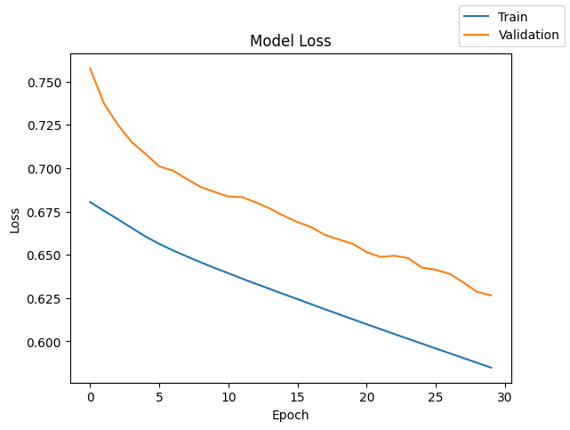

```python
plot(history,'loss')
```

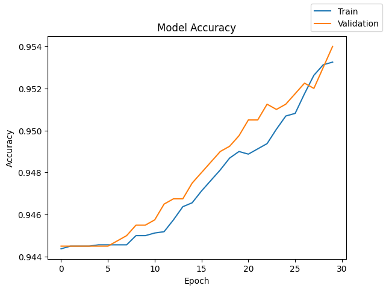

```python
plot(history,'accuracy')
```

```python
#Add an entry to results

results.loc[2] = [1,64,"relu",30,1000,"sgd","0.5:9","-","-","-",history.history["loss"][-1],history.history["val_loss"][-1],history.history["accuracy"][-1],history.history["val_accuracy"][-1],round(end-start,2)]
```

```python
results
```

|  | # hidden layers | # neurons - hidden layer | activation function - hidden layer | # epochs | batch size | optimizer | class weights | learning rate, momentum | weight initializer | regularization | train loss | validation loss | train accuracy | validation accuracy | time (secs) |
| --- | --- | --- | --- | --- | --- | --- | --- | --- | --- | --- | --- | --- | --- | --- | --- |
| 0 | 1 | [64] | [relu] | 30 | 1000 | sgd | - | - | - | - | 0.210152 | 0.209642 | 0.94450 | 0.9445 | 6.95 |
| 1 | 1 | 64 | relu | 30 | 1000 | sgd | 1:5 | - | - | - | 0.567296 | 0.289252 | 0.94450 | 0.9445 | 7.65 |
| 2 | 1 | 64 | relu | 30 | 1000 | sgd | 0.5:9 | - | - | - | 0.584882 | 0.626594 | 0.95325 | 0.9540 | 5.61 |

#### Observations

Observations and notes for Model 2:

Model Architecture: This model is identical to Model 0 and Model 1, consisting of:

1 input layer (matching the 40 features). 1 hidden layer with 64 neurons and relu activation. 1 output layer with 1 neuron and no activation (logits), suitable for BinaryCrossentropy(from_logits=True). Training Configuration:

Epochs: 30 Batch Size: 1000 Optimizer: Stochastic Gradient Descent (SGD) Loss Function: BinaryCrossentropy(from_logits=True) Class Weights: {0: 0.5, 1: 9.0} (applied with an even heavier penalty for misclassifying the minority class) Performance Metrics (after 30 epochs):

Training Loss: ~0.585 Validation Loss: ~0.627 Training Accuracy: ~0.953 Validation Accuracy: ~0.954 Time Taken: ~5.61 seconds

**Observations**: With a further adjusted class weight ratio (0: 0.5, 1: 9.0), the model's accuracy on both the training and validation sets has slightly increased to approximately 0.953 and 0.954 respectively. The training loss (0.585) is higher than Model 0, but the validation loss (0.627) is also considerably higher than both Model 0 and Model 1. While the overall accuracy shows a slight improvement, indicating more correct predictions overall, it's still crucial to assess performance using metrics specifically designed for imbalanced datasets, such as recall, precision, and F1-score for the minority class. The increased loss values suggest that the model is being heavily influenced by the new class weights, likely aiming to reduce false negatives for the minority class, which might come at the cost of overall loss.

### Model 3

1 input, 2 hidden (128,64 nodes), 1 output layers relu, relu activations for the hidden layer Stochastic Gradient Descent (SGD)

Epoch: 50 Batch Size: 500

```python
batch_size = 500
epochs = 50
num_classes=1 #Output is the Target variable alone
```

```python
# clears the current Keras session, resetting all layers and models previously created, freeing up memory and resources.
tf.keras.backend.clear_session()
```

```python
#Initializing the neural network

bce_logits_loss = tf.keras.losses.BinaryCrossentropy(from_logits=True)
optimizer = keras.optimizers.SGD()    # defining SGD as the optimizer to be used

model_1 = Sequential()
model_1.add(Dense(128,activation="relu",input_dim = X_train.shape[1]))
model_1.add(Dense(64,activation="relu"))
model_1.add(Dense(num_classes)) # Removed activation='sigmoid' because from_logits=True is used in the loss function
```

```python
model_1.summary()
```

```
Model: "sequential"
```

```
┏━━━━━━━━━━━━━━━━━━━━━━━━━━━━━━━━━┳━━━━━━━━━━━━━━━━━━━━━━━━┳━━━━━━━━━━━━━━━┓
┃ Layer (type)                    ┃ Output Shape           ┃       Param # ┃
┡━━━━━━━━━━━━━━━━━━━━━━━━━━━━━━━━━╇━━━━━━━━━━━━━━━━━━━━━━━━╇━━━━━━━━━━━━━━━┩
│ dense (Dense)                   │ (None, 128)            │         5,248 │
├─────────────────────────────────┼────────────────────────┼───────────────┤
│ dense_1 (Dense)                 │ (None, 64)             │         8,256 │
├─────────────────────────────────┼────────────────────────┼───────────────┤
│ dense_2 (Dense)                 │ (None, 1)              │            65 │
└─────────────────────────────────┴────────────────────────┴───────────────┘
```

```
 Total params: 13,569 (53.00 KB)
```

```
 Trainable params: 13,569 (53.00 KB)
```

```
 Non-trainable params: 0 (0.00 B)
```

```python
model_1.compile(loss=bce_logits_loss, optimizer=optimizer, metrics=["accuracy"])
```

```python
class_weights = {0: 0.5, 1: 9.0}
start = time.time()
history = model_1.fit(X_train, y_train, validation_data=(X_val,y_val) , class_weight=class_weights, batch_size=batch_size, epochs=epochs)
end=time.time()
```

```
32/32 ━━━━━━━━━━━━━━━━━━━━ 1s 12ms/step - accuracy: 0.9460 - loss: 0.6730 - val_accuracy: 0.9445 - val_loss: 0.7289
32/32 ━━━━━━━━━━━━━━━━━━━━ 0s 7ms/step - accuracy: 0.9448 - loss: 0.6646 - val_accuracy: 0.9445 - val_loss: 0.7121
32/32 ━━━━━━━━━━━━━━━━━━━━ 0s 7ms/step - accuracy: 0.9443 - loss: 0.6585 - val_accuracy: 0.9445 - val_loss: 0.7011
32/32 ━━━━━━━━━━━━━━━━━━━━ 0s 6ms/step - accuracy: 0.9466 - loss: 0.6368 - val_accuracy: 0.9445 - val_loss: 0.6957
32/32 ━━━━━━━━━━━━━━━━━━━━ 0s 7ms/step - accuracy: 0.9433 - loss: 0.6470 - val_accuracy: 0.9445 - val_loss: 0.6781
32/32 ━━━━━━━━━━━━━━━━━━━━ 0s 7ms/step - accuracy: 0.9416 - loss: 0.6438 - val_accuracy: 0.9445 - val_loss: 0.6625
32/32 ━━━━━━━━━━━━━━━━━━━━ 0s 6ms/step - accuracy: 0.9443 - loss: 0.6237 - val_accuracy: 0.9457 - val_loss: 0.6643
32/32 ━━━━━━━━━━━━━━━━━━━━ 0s 6ms/step - accuracy: 0.9455 - loss: 0.6171 - val_accuracy: 0.9485 - val_loss: 0.6552
32/32 ━━━━━━━━━━━━━━━━━━━━ 0s 7ms/step - accuracy: 0.9471 - loss: 0.6085 - val_accuracy: 0.9485 - val_loss: 0.6441
32/32 ━━━━━━━━━━━━━━━━━━━━ 0s 6ms/step - accuracy: 0.9471 - loss: 0.6126 - val_accuracy: 0.9503 - val_loss: 0.6296
32/32 ━━━━━━━━━━━━━━━━━━━━ 0s 7ms/step - accuracy: 0.9511 - loss: 0.5821 - val_accuracy: 0.9545 - val_loss: 0.6386
32/32 ━━━━━━━━━━━━━━━━━━━━ 0s 7ms/step - accuracy: 0.9540 - loss: 0.5814 - val_accuracy: 0.9548 - val_loss: 0.6177
32/32 ━━━━━━━━━━━━━━━━━━━━ 0s 7ms/step - accuracy: 0.9533 - loss: 0.5864 - val_accuracy: 0.9567 - val_loss: 0.6007
32/32 ━━━━━━━━━━━━━━━━━━━━ 0s 7ms/step - accuracy: 0.9560 - loss: 0.5641 - val_accuracy: 0.9578 - val_loss: 0.5883
32/32 ━━━━━━━━━━━━━━━━━━━━ 0s 7ms/step - accuracy: 0.9585 - loss: 0.5353 - val_accuracy: 0.9575 - val_loss: 0.5904
32/32 ━━━━━━━━━━━━━━━━━━━━ 0s 7ms/step - accuracy: 0.9549 - loss: 0.5505 - val_accuracy: 0.9567 - val_loss: 0.5730
32/32 ━━━━━━━━━━━━━━━━━━━━ 0s 8ms/step - accuracy: 0.9557 - loss: 0.5292 - val_accuracy: 0.9538 - val_loss: 0.5599
32/32 ━━━━━━━━━━━━━━━━━━━━ 0s 11ms/step - accuracy: 0.9536 - loss: 0.5221 - val_accuracy: 0.9492 - val_loss: 0.5632
32/32 ━━━━━━━━━━━━━━━━━━━━ 0s 10ms/step - accuracy: 0.9475 - loss: 0.5189 - val_accuracy: 0.9517 - val_loss: 0.5242
32/32 ━━━━━━━━━━━━━━━━━━━━ 0s 10ms/step - accuracy: 0.9502 - loss: 0.5092 - val_accuracy: 0.9490 - val_loss: 0.5225
32/32 ━━━━━━━━━━━━━━━━━━━━ 0s 11ms/step - accuracy: 0.9454 - loss: 0.5038 - val_accuracy: 0.9465 - val_loss: 0.5143
32/32 ━━━━━━━━━━━━━━━━━━━━ 0s 10ms/step - accuracy: 0.9462 - loss: 0.4825 - val_accuracy: 0.9340 - val_loss: 0.5279
32/32 ━━━━━━━━━━━━━━━━━━━━ 0s 10ms/step - accuracy: 0.9454 - loss: 0.4662 - val_accuracy: 0.9260 - val_loss: 0.5245
32/32 ━━━━━━━━━━━━━━━━━━━━ 0s 9ms/step - accuracy: 0.9366 - loss: 0.4628 - val_accuracy: 0.9360 - val_loss: 0.4873
32/32 ━━━━━━━━━━━━━━━━━━━━ 1s 11ms/step - accuracy: 0.9363 - loss: 0.4745 - val_accuracy: 0.9295 - val_loss: 0.4869
32/32 ━━━━━━━━━━━━━━━━━━━━ 0s 12ms/step - accuracy: 0.9319 - loss: 0.4634 - val_accuracy: 0.9438 - val_loss: 0.4349
32/32 ━━━━━━━━━━━━━━━━━━━━ 0s 7ms/step - accuracy: 0.9397 - loss: 0.4439 - val_accuracy: 0.9335 - val_loss: 0.4500
32/32 ━━━━━━━━━━━━━━━━━━━━ 0s 6ms/step - accuracy: 0.9312 - loss: 0.4477 - val_accuracy: 0.9295 - val_loss: 0.4451
32/32 ━━━━━━━━━━━━━━━━━━━━ 0s 7ms/step - accuracy: 0.9250 - loss: 0.4476 - val_accuracy: 0.9298 - val_loss: 0.4336
32/32 ━━━━━━━━━━━━━━━━━━━━ 0s 6ms/step - accuracy: 0.9300 - loss: 0.4225 - val_accuracy: 0.9068 - val_loss: 0.4720
32/32 ━━━━━━━━━━━━━━━━━━━━ 0s 7ms/step - accuracy: 0.9212 - loss: 0.4263 - val_accuracy: 0.9212 - val_loss: 0.4273
32/32 ━━━━━━━━━━━━━━━━━━━━ 0s 7ms/step - accuracy: 0.9266 - loss: 0.4234 - val_accuracy: 0.9308 - val_loss: 0.4029
32/32 ━━━━━━━━━━━━━━━━━━━━ 0s 6ms/step - accuracy: 0.9235 - loss: 0.4215 - val_accuracy: 0.9055 - val_loss: 0.4459
32/32 ━━━━━━━━━━━━━━━━━━━━ 0s 7ms/step - accuracy: 0.9207 - loss: 0.3985 - val_accuracy: 0.9062 - val_loss: 0.4357
32/32 ━━━━━━━━━━━━━━━━━━━━ 0s 6ms/step - accuracy: 0.9190 - loss: 0.4052 - val_accuracy: 0.8995 - val_loss: 0.4479
32/32 ━━━━━━━━━━━━━━━━━━━━ 0s 6ms/step - accuracy: 0.9153 - loss: 0.4045 - val_accuracy: 0.9130 - val_loss: 0.4093
32/32 ━━━━━━━━━━━━━━━━━━━━ 0s 7ms/step - accuracy: 0.9193 - loss: 0.3996 - val_accuracy: 0.9085 - val_loss: 0.4124
32/32 ━━━━━━━━━━━━━━━━━━━━ 0s 8ms/step - accuracy: 0.9224 - loss: 0.3810 - val_accuracy: 0.8988 - val_loss: 0.4298
32/32 ━━━━━━━━━━━━━━━━━━━━ 0s 7ms/step - accuracy: 0.9109 - loss: 0.3903 - val_accuracy: 0.9125 - val_loss: 0.3936
32/32 ━━━━━━━━━━━━━━━━━━━━ 0s 7ms/step - accuracy: 0.9261 - loss: 0.3757 - val_accuracy: 0.9093 - val_loss: 0.4006
32/32 ━━━━━━━━━━━━━━━━━━━━ 0s 7ms/step - accuracy: 0.9192 - loss: 0.3811 - val_accuracy: 0.9153 - val_loss: 0.3768
32/32 ━━━━━━━━━━━━━━━━━━━━ 0s 7ms/step - accuracy: 0.9175 - loss: 0.3842 - val_accuracy: 0.9085 - val_loss: 0.3932
32/32 ━━━━━━━━━━━━━━━━━━━━ 0s 7ms/step - accuracy: 0.9173 - loss: 0.3768 - val_accuracy: 0.9062 - val_loss: 0.3978
32/32 ━━━━━━━━━━━━━━━━━━━━ 0s 7ms/step - accuracy: 0.9073 - loss: 0.3785 - val_accuracy: 0.9115 - val_loss: 0.3797
32/32 ━━━━━━━━━━━━━━━━━━━━ 0s 7ms/step - accuracy: 0.9192 - loss: 0.3758 - val_accuracy: 0.9072 - val_loss: 0.3894
32/32 ━━━━━━━━━━━━━━━━━━━━ 0s 7ms/step - accuracy: 0.9164 - loss: 0.3638 - val_accuracy: 0.9190 - val_loss: 0.3527
32/32 ━━━━━━━━━━━━━━━━━━━━ 0s 7ms/step - accuracy: 0.9146 - loss: 0.3892 - val_accuracy: 0.9103 - val_loss: 0.3759
32/32 ━━━━━━━━━━━━━━━━━━━━ 0s 7ms/step - accuracy: 0.9125 - loss: 0.3826 - val_accuracy: 0.9175 - val_loss: 0.3525
32/32 ━━━━━━━━━━━━━━━━━━━━ 0s 7ms/step - accuracy: 0.9123 - loss: 0.3763 - val_accuracy: 0.9233 - val_loss: 0.3386
32/32 ━━━━━━━━━━━━━━━━━━━━ 0s 7ms/step - accuracy: 0.9183 - loss: 0.3652 - val_accuracy: 0.9095 - val_loss: 0.3730
```

```python
print("Time taken in seconds ",end-start)
```

```
Time taken in seconds  14.439069986343384
```

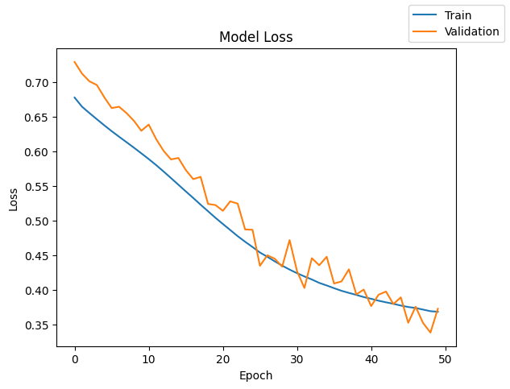

```python
plot(history,'loss')
```

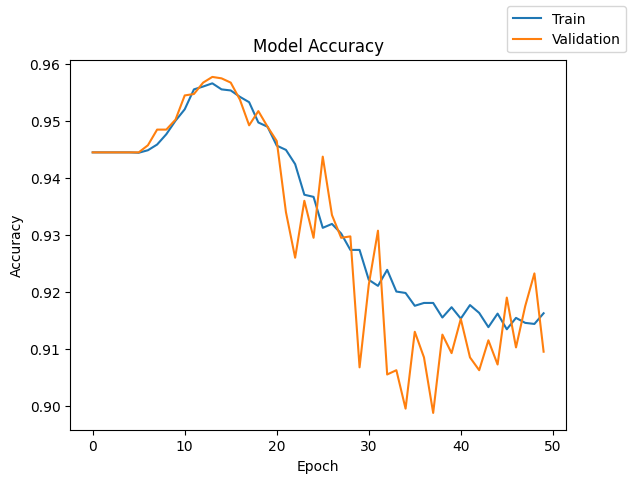

```python
plot(history,'accuracy')
```

```python
#Add an entry to results

results.loc[3] = [2,"128,64","relu,relu",50,500,"sgd","0.5:9","-","-","-",history.history["loss"][-1],history.history["val_loss"][-1],history.history["accuracy"][-1],history.history["val_accuracy"][-1],round(end-start,2)]
```

```python
results
```

|  | # hidden layers | # neurons - hidden layer | activation function - hidden layer | # epochs | batch size | optimizer | class weights | learning rate, momentum | weight initializer | regularization | train loss | validation loss | train accuracy | validation accuracy | time (secs) |
| --- | --- | --- | --- | --- | --- | --- | --- | --- | --- | --- | --- | --- | --- | --- | --- |
| 0 | 1 | [64] | [relu] | 30 | 1000 | sgd | - | - | - | - | 0.210152 | 0.209642 | 0.94450 | 0.9445 | 6.95 |
| 1 | 1 | 64 | relu | 30 | 1000 | sgd | 1:5 | - | - | - | 0.567296 | 0.289252 | 0.94450 | 0.9445 | 7.65 |
| 2 | 1 | 64 | relu | 30 | 1000 | sgd | 0.5:9 | - | - | - | 0.584882 | 0.626594 | 0.95325 | 0.9540 | 5.61 |
| 3 | 2 | 128,64 | relu,relu | 50 | 500 | sgd | 0.5:9 | - | - | - | 0.368593 | 0.372975 | 0.91625 | 0.9095 | 14.44 |

### Observations

Observations and notes for Model 3:

Model Architecture: This model features a deeper architecture compared to the previous models:

1 input layer (matching the 40 features). 2 hidden layers: the first with 128 neurons and relu activation, and the second with 64 neurons and relu activation. 1 output layer with 1 neuron and no activation (logits), suitable for BinaryCrossentropy(from_logits=True).

Training Configuration:

Epochs: 50 Batch Size: 500 Optimizer: Stochastic Gradient Descent (SGD) Loss Function: BinaryCrossentropy(from_logits=True) Class Weights: {0: 0.5, 1: 9.0} (same as Model 2)

Performance Metrics (after 50 epochs):

Training Loss: ~0.369 Validation Loss: ~0.373 Training Accuracy: ~0.916 Validation Accuracy: ~0.9095 Time Taken: ~14.44 seconds

### Model 4

Epoch: 50 Batch Size: 500

```python
batch_size = 500
epochs = 50
num_classes=1 #Output is the Target variable alone
```

```python
# clears the current Keras session, resetting all layers and models previously created, freeing up memory and resources.
tf.keras.backend.clear_session()
```

```python
#Initializing the neural network

bce_logits_loss = tf.keras.losses.BinaryCrossentropy(from_logits=True)
optimizer = keras.optimizers.Adam()    # defining Adam as the optimizer to be used

model_1 = Sequential()
model_1.add(Dense(128,activation="relu",input_dim = X_train.shape[1]))
model_1.add(Dense(64,activation="relu"))
model_1.add(Dense(num_classes)) # Removed activation='sigmoid' because from_logits=True is used in the loss function
```

```python
model_1.summary()
```

```
Model: "sequential"
```

```
┏━━━━━━━━━━━━━━━━━━━━━━━━━━━━━━━━━┳━━━━━━━━━━━━━━━━━━━━━━━━┳━━━━━━━━━━━━━━━┓
┃ Layer (type)                    ┃ Output Shape           ┃       Param # ┃
┡━━━━━━━━━━━━━━━━━━━━━━━━━━━━━━━━━╇━━━━━━━━━━━━━━━━━━━━━━━━╇━━━━━━━━━━━━━━━┩
│ dense (Dense)                   │ (None, 128)            │         5,248 │
├─────────────────────────────────┼────────────────────────┼───────────────┤
│ dense_1 (Dense)                 │ (None, 64)             │         8,256 │
├─────────────────────────────────┼────────────────────────┼───────────────┤
│ dense_2 (Dense)                 │ (None, 1)              │            65 │
└─────────────────────────────────┴────────────────────────┴───────────────┘
```

```
 Total params: 13,569 (53.00 KB)
```

```
 Trainable params: 13,569 (53.00 KB)
```

```
 Non-trainable params: 0 (0.00 B)
```

```python
model_1.compile(loss=bce_logits_loss, optimizer=optimizer, metrics=["accuracy"])
```

```python
class_weights = {0: 0.5, 1: 9.0}
start = time.time()
history = model_1.fit(X_train, y_train, validation_data=(X_val,y_val) , class_weight=class_weights, batch_size=batch_size, epochs=epochs)
end=time.time()
```

```
32/32 ━━━━━━━━━━━━━━━━━━━━ 2s 13ms/step - accuracy: 0.9490 - loss: 0.6194 - val_accuracy: 0.9442 - val_loss: 0.5360
32/32 ━━━━━━━━━━━━━━━━━━━━ 0s 7ms/step - accuracy: 0.9255 - loss: 0.4881 - val_accuracy: 0.8447 - val_loss: 0.5465
32/32 ━━━━━━━━━━━━━━━━━━━━ 0s 7ms/step - accuracy: 0.8915 - loss: 0.4173 - val_accuracy: 0.9047 - val_loss: 0.3718
32/32 ━━━━━━━━━━━━━━━━━━━━ 0s 7ms/step - accuracy: 0.8959 - loss: 0.3825 - val_accuracy: 0.8813 - val_loss: 0.4180
32/32 ━━━━━━━━━━━━━━━━━━━━ 0s 7ms/step - accuracy: 0.9147 - loss: 0.3559 - val_accuracy: 0.9360 - val_loss: 0.2779
32/32 ━━━━━━━━━━━━━━━━━━━━ 0s 7ms/step - accuracy: 0.9223 - loss: 0.3333 - val_accuracy: 0.9360 - val_loss: 0.2827
32/32 ━━━━━━━━━━━━━━━━━━━━ 0s 7ms/step - accuracy: 0.9255 - loss: 0.3351 - val_accuracy: 0.9315 - val_loss: 0.2855
32/32 ━━━━━━━━━━━━━━━━━━━━ 0s 7ms/step - accuracy: 0.9212 - loss: 0.3329 - val_accuracy: 0.9258 - val_loss: 0.3025
32/32 ━━━━━━━━━━━━━━━━━━━━ 0s 7ms/step - accuracy: 0.9242 - loss: 0.3222 - val_accuracy: 0.9385 - val_loss: 0.2709
32/32 ━━━━━━━━━━━━━━━━━━━━ 0s 8ms/step - accuracy: 0.9340 - loss: 0.3089 - val_accuracy: 0.9402 - val_loss: 0.2686
32/32 ━━━━━━━━━━━━━━━━━━━━ 0s 7ms/step - accuracy: 0.9362 - loss: 0.3064 - val_accuracy: 0.9197 - val_loss: 0.3180
32/32 ━━━━━━━━━━━━━━━━━━━━ 0s 7ms/step - accuracy: 0.9319 - loss: 0.2879 - val_accuracy: 0.9610 - val_loss: 0.2080
32/32 ━━━━━━━━━━━━━━━━━━━━ 0s 7ms/step - accuracy: 0.9458 - loss: 0.2723 - val_accuracy: 0.9427 - val_loss: 0.2739
32/32 ━━━━━━━━━━━━━━━━━━━━ 0s 7ms/step - accuracy: 0.9470 - loss: 0.2635 - val_accuracy: 0.9260 - val_loss: 0.3111
32/32 ━━━━━━━━━━━━━━━━━━━━ 0s 7ms/step - accuracy: 0.9380 - loss: 0.2915 - val_accuracy: 0.9645 - val_loss: 0.1936
32/32 ━━━━━━━━━━━━━━━━━━━━ 0s 7ms/step - accuracy: 0.9505 - loss: 0.2510 - val_accuracy: 0.9650 - val_loss: 0.1974
32/32 ━━━━━━━━━━━━━━━━━━━━ 0s 7ms/step - accuracy: 0.9561 - loss: 0.2801 - val_accuracy: 0.9725 - val_loss: 0.1704
32/32 ━━━━━━━━━━━━━━━━━━━━ 0s 7ms/step - accuracy: 0.9584 - loss: 0.2882 - val_accuracy: 0.9470 - val_loss: 0.2489
32/32 ━━━━━━━━━━━━━━━━━━━━ 0s 7ms/step - accuracy: 0.9526 - loss: 0.2330 - val_accuracy: 0.9753 - val_loss: 0.1713
32/32 ━━━━━━━━━━━━━━━━━━━━ 0s 7ms/step - accuracy: 0.9658 - loss: 0.2449 - val_accuracy: 0.9720 - val_loss: 0.1807
32/32 ━━━━━━━━━━━━━━━━━━━━ 0s 7ms/step - accuracy: 0.9682 - loss: 0.2275 - val_accuracy: 0.9725 - val_loss: 0.1813
32/32 ━━━━━━━━━━━━━━━━━━━━ 0s 7ms/step - accuracy: 0.9687 - loss: 0.2367 - val_accuracy: 0.9515 - val_loss: 0.2458
32/32 ━━━━━━━━━━━━━━━━━━━━ 0s 7ms/step - accuracy: 0.9656 - loss: 0.2299 - val_accuracy: 0.9778 - val_loss: 0.1460
32/32 ━━━━━━━━━━━━━━━━━━━━ 0s 7ms/step - accuracy: 0.9708 - loss: 0.2136 - val_accuracy: 0.9680 - val_loss: 0.2025
32/32 ━━━━━━━━━━━━━━━━━━━━ 0s 7ms/step - accuracy: 0.9704 - loss: 0.2186 - val_accuracy: 0.9670 - val_loss: 0.2054
32/32 ━━━━━━━━━━━━━━━━━━━━ 0s 7ms/step - accuracy: 0.9701 - loss: 0.2266 - val_accuracy: 0.9755 - val_loss: 0.1485
32/32 ━━━━━━━━━━━━━━━━━━━━ 0s 7ms/step - accuracy: 0.9672 - loss: 0.2237 - val_accuracy: 0.9778 - val_loss: 0.1785
32/32 ━━━━━━━━━━━━━━━━━━━━ 0s 7ms/step - accuracy: 0.9722 - loss: 0.2165 - val_accuracy: 0.9657 - val_loss: 0.1861
32/32 ━━━━━━━━━━━━━━━━━━━━ 0s 7ms/step - accuracy: 0.9654 - loss: 0.2199 - val_accuracy: 0.9672 - val_loss: 0.2046
32/32 ━━━━━━━━━━━━━━━━━━━━ 0s 7ms/step - accuracy: 0.9720 - loss: 0.2124 - val_accuracy: 0.9693 - val_loss: 0.1866
32/32 ━━━━━━━━━━━━━━━━━━━━ 0s 11ms/step - accuracy: 0.9723 - loss: 0.1932 - val_accuracy: 0.9755 - val_loss: 0.1856
32/32 ━━━━━━━━━━━━━━━━━━━━ 1s 21ms/step - accuracy: 0.9737 - loss: 0.2067 - val_accuracy: 0.9822 - val_loss: 0.1347
32/32 ━━━━━━━━━━━━━━━━━━━━ 1s 21ms/step - accuracy: 0.9779 - loss: 0.1829 - val_accuracy: 0.9707 - val_loss: 0.1905
32/32 ━━━━━━━━━━━━━━━━━━━━ 1s 31ms/step - accuracy: 0.9780 - loss: 0.1903 - val_accuracy: 0.9765 - val_loss: 0.1689
32/32 ━━━━━━━━━━━━━━━━━━━━ 0s 12ms/step - accuracy: 0.9770 - loss: 0.1942 - val_accuracy: 0.9440 - val_loss: 0.2659
32/32 ━━━━━━━━━━━━━━━━━━━━ 0s 14ms/step - accuracy: 0.9728 - loss: 0.2081 - val_accuracy: 0.9760 - val_loss: 0.1617
32/32 ━━━━━━━━━━━━━━━━━━━━ 1s 19ms/step - accuracy: 0.9778 - loss: 0.1942 - val_accuracy: 0.9790 - val_loss: 0.1530
32/32 ━━━━━━━━━━━━━━━━━━━━ 2s 46ms/step - accuracy: 0.9752 - loss: 0.1882 - val_accuracy: 0.9745 - val_loss: 0.1911
32/32 ━━━━━━━━━━━━━━━━━━━━ 1s 32ms/step - accuracy: 0.9768 - loss: 0.2204 - val_accuracy: 0.9845 - val_loss: 0.1150
32/32 ━━━━━━━━━━━━━━━━━━━━ 1s 11ms/step - accuracy: 0.9796 - loss: 0.2023 - val_accuracy: 0.9320 - val_loss: 0.2968
32/32 ━━━━━━━━━━━━━━━━━━━━ 0s 6ms/step - accuracy: 0.9722 - loss: 0.2126 - val_accuracy: 0.9760 - val_loss: 0.1479
32/32 ━━━━━━━━━━━━━━━━━━━━ 0s 8ms/step - accuracy: 0.9669 - loss: 0.2235 - val_accuracy: 0.9822 - val_loss: 0.1237
32/32 ━━━━━━━━━━━━━━━━━━━━ 0s 7ms/step - accuracy: 0.9786 - loss: 0.1745 - val_accuracy: 0.9808 - val_loss: 0.1903
32/32 ━━━━━━━━━━━━━━━━━━━━ 0s 7ms/step - accuracy: 0.9772 - loss: 0.1811 - val_accuracy: 0.9680 - val_loss: 0.2222
32/32 ━━━━━━━━━━━━━━━━━━━━ 0s 7ms/step - accuracy: 0.9770 - loss: 0.1953 - val_accuracy: 0.9835 - val_loss: 0.1267
32/32 ━━━━━━━━━━━━━━━━━━━━ 0s 7ms/step - accuracy: 0.9772 - loss: 0.2151 - val_accuracy: 0.9745 - val_loss: 0.1464
32/32 ━━━━━━━━━━━━━━━━━━━━ 0s 7ms/step - accuracy: 0.9754 - loss: 0.1917 - val_accuracy: 0.9732 - val_loss: 0.1823
32/32 ━━━━━━━━━━━━━━━━━━━━ 0s 8ms/step - accuracy: 0.9755 - loss: 0.1774 - val_accuracy: 0.9858 - val_loss: 0.1483
32/32 ━━━━━━━━━━━━━━━━━━━━ 0s 14ms/step - accuracy: 0.9799 - loss: 0.1799 - val_accuracy: 0.9523 - val_loss: 0.2596
32/32 ━━━━━━━━━━━━━━━━━━━━ 0s 9ms/step - accuracy: 0.9735 - loss: 0.1912 - val_accuracy: 0.9755 - val_loss: 0.1921
```

```python
print("Time taken in seconds ",end-start)
```

```
Time taken in seconds  20.090774059295654
```

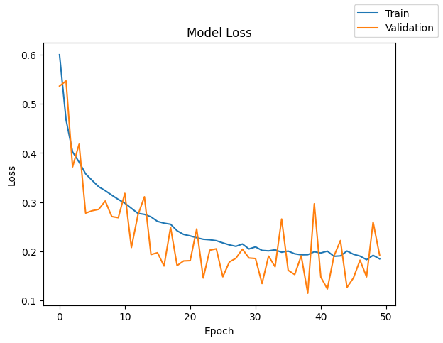

```python
plot(history,'loss')
```

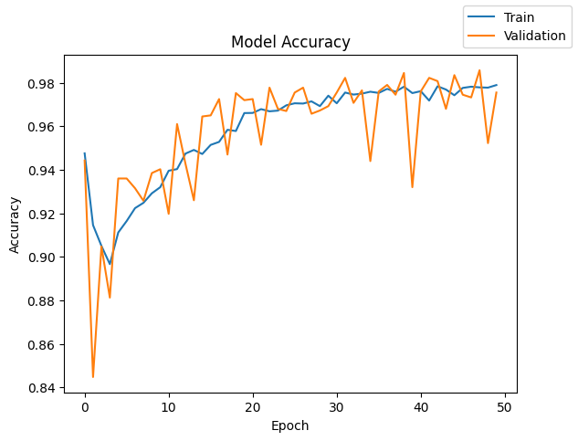

```python
plot(history,'accuracy')
```

```python
#Add an entry to results

results.loc[4] = [2,"128,64","relu,relu",50,500,"adam","0.5:9","-","-","-",history.history["loss"][-1],history.history["val_loss"][-1],history.history["accuracy"][-1],history.history["val_accuracy"][-1],round(end-start,2)]
```

```python
results
```

|  | # hidden layers | # neurons - hidden layer | activation function - hidden layer | # epochs | batch size | optimizer | class weights | learning rate, momentum | weight initializer | regularization | train loss | validation loss | train accuracy | validation accuracy | time (secs) |
| --- | --- | --- | --- | --- | --- | --- | --- | --- | --- | --- | --- | --- | --- | --- | --- |
| 0 | 1 | [64] | [relu] | 30 | 1000 | sgd | - | - | - | - | 0.210152 | 0.209642 | 0.944500 | 0.9445 | 6.95 |
| 1 | 1 | 64 | relu | 30 | 1000 | sgd | 1:5 | - | - | - | 0.567296 | 0.289252 | 0.944500 | 0.9445 | 7.65 |
| 2 | 1 | 64 | relu | 30 | 1000 | sgd | 0.5:9 | - | - | - | 0.584882 | 0.626594 | 0.953250 | 0.9540 | 5.61 |
| 3 | 2 | 128,64 | relu,relu | 50 | 500 | sgd | 0.5:9 | - | - | - | 0.368593 | 0.372975 | 0.916250 | 0.9095 | 14.44 |
| 4 | 2 | 128,64 | relu,relu | 50 | 500 | adam | 0.5:9 | - | - | - | 0.184864 | 0.192104 | 0.978938 | 0.9755 | 20.09 |

### Observations

Observations and notes for Model 4:

Model Architecture: This model retains the deeper architecture introduced in Model 3:

1 input layer (matching the 40 features). 2 hidden layers: the first with 128 neurons and relu activation, and the second with 64 neurons and relu activation. 1 output layer with 1 neuron and no activation (logits), suitable for BinaryCrossentropy(from_logits=True).

Training Configuration:

Epochs: 50 Batch Size: 500 Optimizer: Adam (changed from SGD in Model 3) Loss Function: BinaryCrossentropy(from_logits=True) Class Weights: {0: 0.5, 1: 9.0} (same as Model 3)

Performance Metrics (after 50 epochs):

Training Loss: ~0.185 Validation Loss: ~0.192 Training Accuracy: ~0.979 Validation Accuracy: ~0.9755 Time Taken: ~20.09 seconds

Observations: The switch to the Adam optimizer in Model 4 has significantly improved performance compared to Model 3, and even compared to the earlier models.

### Model 5

Epoch: 50 Batch Size: 500

```python
batch_size = 500
epochs = 50
num_classes=1 #Output is the Target variable alone
```

```python
# clears the current Keras session, resetting all layers and models previously created, freeing up memory and resources.
tf.keras.backend.clear_session()
```

```python
#Initializing the neural network

bce_logits_loss = tf.keras.losses.BinaryCrossentropy(from_logits=True)
optimizer = keras.optimizers.Adam()    # defining Adam as the optimizer to be used

model_1 = Sequential()
model_1.add(Dense(128,activation="relu",input_dim = X_train.shape[1]))
model_1.add(Dropout(0.3))
model_1.add(Dense(64,activation="relu"))
model_1.add(Dense(num_classes)) # Removed activation='sigmoid' because from_logits=True is used in the loss function
```

```python
model_1.summary()
```

```
Model: "sequential"
```

```
┏━━━━━━━━━━━━━━━━━━━━━━━━━━━━━━━━━┳━━━━━━━━━━━━━━━━━━━━━━━━┳━━━━━━━━━━━━━━━┓
┃ Layer (type)                    ┃ Output Shape           ┃       Param # ┃
┡━━━━━━━━━━━━━━━━━━━━━━━━━━━━━━━━━╇━━━━━━━━━━━━━━━━━━━━━━━━╇━━━━━━━━━━━━━━━┩
│ dense (Dense)                   │ (None, 128)            │         5,248 │
├─────────────────────────────────┼────────────────────────┼───────────────┤
│ dropout (Dropout)               │ (None, 128)            │             0 │
├─────────────────────────────────┼────────────────────────┼───────────────┤
│ dense_1 (Dense)                 │ (None, 64)             │         8,256 │
├─────────────────────────────────┼────────────────────────┼───────────────┤
│ dense_2 (Dense)                 │ (None, 1)              │            65 │
└─────────────────────────────────┴────────────────────────┴───────────────┘
```

```
 Total params: 13,569 (53.00 KB)
```

```
 Trainable params: 13,569 (53.00 KB)
```

```
 Non-trainable params: 0 (0.00 B)
```

```python
model_1.compile(loss=bce_logits_loss, optimizer=optimizer, metrics=["accuracy"])
```

```python
class_weights = {0: 0.5, 1: 9.0}
start = time.time()
history = model_1.fit(X_train, y_train, validation_data=(X_val,y_val) , class_weight=class_weights, batch_size=batch_size, epochs=epochs)
end=time.time()
```

```
32/32 ━━━━━━━━━━━━━━━━━━━━ 2s 14ms/step - accuracy: 0.9337 - loss: 0.6524 - val_accuracy: 0.9433 - val_loss: 0.6138
32/32 ━━━━━━━━━━━━━━━━━━━━ 0s 7ms/step - accuracy: 0.9061 - loss: 0.5293 - val_accuracy: 0.9208 - val_loss: 0.4118
32/32 ━━━━━━━━━━━━━━━━━━━━ 0s 8ms/step - accuracy: 0.8939 - loss: 0.4375 - val_accuracy: 0.8577 - val_loss: 0.4784
32/32 ━━━━━━━━━━━━━━━━━━━━ 0s 8ms/step - accuracy: 0.8810 - loss: 0.4048 - val_accuracy: 0.9062 - val_loss: 0.3734
32/32 ━━━━━━━━━━━━━━━━━━━━ 0s 8ms/step - accuracy: 0.9141 - loss: 0.3509 - val_accuracy: 0.9463 - val_loss: 0.2540
32/32 ━━━━━━━━━━━━━━━━━━━━ 0s 7ms/step - accuracy: 0.9131 - loss: 0.3529 - val_accuracy: 0.9523 - val_loss: 0.2240
32/32 ━━━━━━━━━━━━━━━━━━━━ 0s 8ms/step - accuracy: 0.9276 - loss: 0.3481 - val_accuracy: 0.9335 - val_loss: 0.2665
32/32 ━━━━━━━━━━━━━━━━━━━━ 0s 8ms/step - accuracy: 0.9258 - loss: 0.3142 - val_accuracy: 0.9420 - val_loss: 0.2609
32/32 ━━━━━━━━━━━━━━━━━━━━ 0s 8ms/step - accuracy: 0.9282 - loss: 0.3190 - val_accuracy: 0.9507 - val_loss: 0.2339
32/32 ━━━━━━━━━━━━━━━━━━━━ 0s 8ms/step - accuracy: 0.9305 - loss: 0.3146 - val_accuracy: 0.9302 - val_loss: 0.2898
32/32 ━━━━━━━━━━━━━━━━━━━━ 0s 7ms/step - accuracy: 0.9310 - loss: 0.2947 - val_accuracy: 0.9613 - val_loss: 0.2116
32/32 ━━━━━━━━━━━━━━━━━━━━ 0s 8ms/step - accuracy: 0.9450 - loss: 0.2927 - val_accuracy: 0.9457 - val_loss: 0.2441
32/32 ━━━━━━━━━━━━━━━━━━━━ 0s 8ms/step - accuracy: 0.9452 - loss: 0.2863 - val_accuracy: 0.9160 - val_loss: 0.3312
32/32 ━━━━━━━━━━━━━━━━━━━━ 0s 7ms/step - accuracy: 0.9353 - loss: 0.2732 - val_accuracy: 0.9375 - val_loss: 0.2807
32/32 ━━━━━━━━━━━━━━━━━━━━ 0s 8ms/step - accuracy: 0.9477 - loss: 0.2694 - val_accuracy: 0.9540 - val_loss: 0.2572
32/32 ━━━━━━━━━━━━━━━━━━━━ 0s 9ms/step - accuracy: 0.9544 - loss: 0.2577 - val_accuracy: 0.9500 - val_loss: 0.2463
32/32 ━━━━━━━━━━━━━━━━━━━━ 0s 8ms/step - accuracy: 0.9562 - loss: 0.2554 - val_accuracy: 0.9515 - val_loss: 0.2382
32/32 ━━━━━━━━━━━━━━━━━━━━ 0s 9ms/step - accuracy: 0.9544 - loss: 0.2456 - val_accuracy: 0.9785 - val_loss: 0.1750
32/32 ━━━━━━━━━━━━━━━━━━━━ 0s 8ms/step - accuracy: 0.9569 - loss: 0.2803 - val_accuracy: 0.9678 - val_loss: 0.1857
32/32 ━━━━━━━━━━━━━━━━━━━━ 0s 8ms/step - accuracy: 0.9611 - loss: 0.2586 - val_accuracy: 0.9565 - val_loss: 0.2172
32/32 ━━━━━━━━━━━━━━━━━━━━ 0s 8ms/step - accuracy: 0.9655 - loss: 0.2530 - val_accuracy: 0.9758 - val_loss: 0.1535
32/32 ━━━━━━━━━━━━━━━━━━━━ 0s 9ms/step - accuracy: 0.9637 - loss: 0.2367 - val_accuracy: 0.9770 - val_loss: 0.1746
32/32 ━━━━━━━━━━━━━━━━━━━━ 0s 14ms/step - accuracy: 0.9673 - loss: 0.2535 - val_accuracy: 0.9548 - val_loss: 0.2189
32/32 ━━━━━━━━━━━━━━━━━━━━ 1s 12ms/step - accuracy: 0.9673 - loss: 0.2173 - val_accuracy: 0.9465 - val_loss: 0.2606
32/32 ━━━━━━━━━━━━━━━━━━━━ 1s 13ms/step - accuracy: 0.9606 - loss: 0.2403 - val_accuracy: 0.9650 - val_loss: 0.2135
32/32 ━━━━━━━━━━━━━━━━━━━━ 0s 12ms/step - accuracy: 0.9643 - loss: 0.2322 - val_accuracy: 0.9797 - val_loss: 0.1515
32/32 ━━━━━━━━━━━━━━━━━━━━ 0s 13ms/step - accuracy: 0.9707 - loss: 0.2116 - val_accuracy: 0.9815 - val_loss: 0.1480
32/32 ━━━━━━━━━━━━━━━━━━━━ 1s 14ms/step - accuracy: 0.9720 - loss: 0.2098 - val_accuracy: 0.9710 - val_loss: 0.2084
32/32 ━━━━━━━━━━━━━━━━━━━━ 0s 12ms/step - accuracy: 0.9675 - loss: 0.2289 - val_accuracy: 0.9678 - val_loss: 0.1919
32/32 ━━━━━━━━━━━━━━━━━━━━ 0s 8ms/step - accuracy: 0.9695 - loss: 0.2057 - val_accuracy: 0.9805 - val_loss: 0.1583
32/32 ━━━━━━━━━━━━━━━━━━━━ 0s 8ms/step - accuracy: 0.9745 - loss: 0.2207 - val_accuracy: 0.9808 - val_loss: 0.1684
32/32 ━━━━━━━━━━━━━━━━━━━━ 0s 9ms/step - accuracy: 0.9716 - loss: 0.2294 - val_accuracy: 0.9753 - val_loss: 0.1593
32/32 ━━━━━━━━━━━━━━━━━━━━ 0s 8ms/step - accuracy: 0.9705 - loss: 0.2266 - val_accuracy: 0.9728 - val_loss: 0.1690
32/32 ━━━━━━━━━━━━━━━━━━━━ 0s 8ms/step - accuracy: 0.9643 - loss: 0.2165 - val_accuracy: 0.9688 - val_loss: 0.1916
32/32 ━━━━━━━━━━━━━━━━━━━━ 0s 8ms/step - accuracy: 0.9690 - loss: 0.2242 - val_accuracy: 0.9695 - val_loss: 0.1760
32/32 ━━━━━━━━━━━━━━━━━━━━ 0s 8ms/step - accuracy: 0.9711 - loss: 0.2042 - val_accuracy: 0.9820 - val_loss: 0.1309
32/32 ━━━━━━━━━━━━━━━━━━━━ 0s 8ms/step - accuracy: 0.9719 - loss: 0.2009 - val_accuracy: 0.9870 - val_loss: 0.1373
32/32 ━━━━━━━━━━━━━━━━━━━━ 0s 8ms/step - accuracy: 0.9741 - loss: 0.2141 - val_accuracy: 0.9840 - val_loss: 0.1412
32/32 ━━━━━━━━━━━━━━━━━━━━ 0s 8ms/step - accuracy: 0.9708 - loss: 0.2094 - val_accuracy: 0.9808 - val_loss: 0.1401
32/32 ━━━━━━━━━━━━━━━━━━━━ 0s 8ms/step - accuracy: 0.9705 - loss: 0.2047 - val_accuracy: 0.9790 - val_loss: 0.1829
32/32 ━━━━━━━━━━━━━━━━━━━━ 0s 8ms/step - accuracy: 0.9748 - loss: 0.1894 - val_accuracy: 0.9805 - val_loss: 0.1645
32/32 ━━━━━━━━━━━━━━━━━━━━ 0s 9ms/step - accuracy: 0.9738 - loss: 0.2075 - val_accuracy: 0.9827 - val_loss: 0.1426
32/32 ━━━━━━━━━━━━━━━━━━━━ 0s 8ms/step - accuracy: 0.9704 - loss: 0.2168 - val_accuracy: 0.9833 - val_loss: 0.1283
32/32 ━━━━━━━━━━━━━━━━━━━━ 0s 8ms/step - accuracy: 0.9712 - loss: 0.2270 - val_accuracy: 0.9827 - val_loss: 0.1299
32/32 ━━━━━━━━━━━━━━━━━━━━ 0s 8ms/step - accuracy: 0.9759 - loss: 0.2226 - val_accuracy: 0.9797 - val_loss: 0.1495
32/32 ━━━━━━━━━━━━━━━━━━━━ 0s 9ms/step - accuracy: 0.9696 - loss: 0.2212 - val_accuracy: 0.9820 - val_loss: 0.1386
32/32 ━━━━━━━━━━━━━━━━━━━━ 0s 8ms/step - accuracy: 0.9794 - loss: 0.1965 - val_accuracy: 0.9797 - val_loss: 0.1705
32/32 ━━━━━━━━━━━━━━━━━━━━ 0s 8ms/step - accuracy: 0.9785 - loss: 0.1978 - val_accuracy: 0.9858 - val_loss: 0.1428
32/32 ━━━━━━━━━━━━━━━━━━━━ 0s 8ms/step - accuracy: 0.9791 - loss: 0.2062 - val_accuracy: 0.9810 - val_loss: 0.1488
32/32 ━━━━━━━━━━━━━━━━━━━━ 0s 8ms/step - accuracy: 0.9760 - loss: 0.2007 - val_accuracy: 0.9700 - val_loss: 0.1791
```

```python
print("Time taken in seconds ",end-start)
```

```
Time taken in seconds  18.27515459060669
```

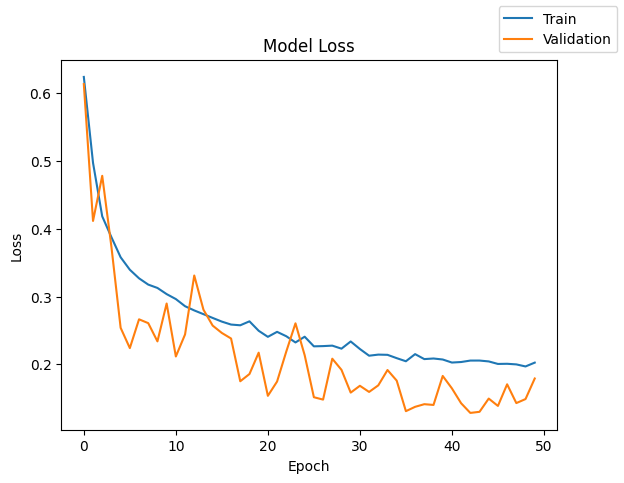

```python
plot(history,'loss')
```

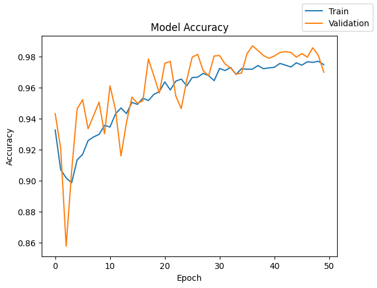

```python
plot(history,'accuracy')
```

```python
#Add an entry to results

results.loc[5] = [2,"128,64","relu,relu",50,500,"adam","0.5:9","-","-","dropout",history.history["loss"][-1],history.history["val_loss"][-1],history.history["accuracy"][-1],history.history["val_accuracy"][-1],round(end-start,2)]
```

```python
results
```

|  | # hidden layers | # neurons - hidden layer | activation function - hidden layer | # epochs | batch size | optimizer | class weights | learning rate, momentum | weight initializer | regularization | train loss | validation loss | train accuracy | validation accuracy | time (secs) |
| --- | --- | --- | --- | --- | --- | --- | --- | --- | --- | --- | --- | --- | --- | --- | --- |
| 0 | 1 | [64] | [relu] | 30 | 1000 | sgd | - | - | - | - | 0.210152 | 0.209642 | 0.944500 | 0.9445 | 6.95 |
| 1 | 1 | 64 | relu | 30 | 1000 | sgd | 1:5 | - | - | - | 0.567296 | 0.289252 | 0.944500 | 0.9445 | 7.65 |
| 2 | 1 | 64 | relu | 30 | 1000 | sgd | 0.5:9 | - | - | - | 0.584882 | 0.626594 | 0.953250 | 0.9540 | 5.61 |
| 3 | 2 | 128,64 | relu,relu | 50 | 500 | sgd | 0.5:9 | - | - | - | 0.368593 | 0.372975 | 0.916250 | 0.9095 | 14.44 |
| 4 | 2 | 128,64 | relu,relu | 50 | 500 | adam | 0.5:9 | - | - | - | 0.184864 | 0.192104 | 0.978938 | 0.9755 | 20.09 |
| 5 | 2 | 128,64 | relu,relu | 50 | 500 | adam | 0.5:9 | - | - | dropout | 0.202561 | 0.179111 | 0.974875 | 0.9700 | 18.28 |

### Observations

Observations and notes for Model 5:

Model Architecture: This model is based on the deeper architecture from Model 3 and Model 4, but with an added Dropout layer:

1 input layer (matching the 40 features). First hidden layer with 128 neurons and relu activation. Dropout layer with a rate of 0.3 (applied after the first hidden layer). Second hidden layer with 64 neurons and relu activation. 1 output layer with 1 neuron and no activation (logits), suitable for BinaryCrossentropy(from_logits=True). Training Configuration:

Epochs: 50 Batch Size: 500 Optimizer: Adam Loss Function: BinaryCrossentropy(from_logits=True) Class Weights: {0: 0.5, 1: 9.0} (same as Model 3 and Model 4) Performance Metrics (after 50 epochs):

Training Loss: ~0.203 Validation Loss: ~0.179 Training Accuracy: ~0.975 Validation Accuracy: ~0.970 Time Taken: ~18.28 seconds Observations: The introduction of a Dropout layer in Model 5, while maintaining the same architecture and hyperparameters as Model 4, has resulted in a slight change in performance.

Accuracy: Both training accuracy (0.975) and validation accuracy (0.970) remain very high, comparable to Model 4, but with a minor decrease. This suggests that the model is still performing very well overall. Loss: Training loss (0.203) and validation loss (0.179) are also very low, indicating effective learning. The validation loss is slightly lower than the training loss, which is a good sign, though it fluctuates. Overfitting Reduction: The primary purpose of Dropout is to prevent overfitting. While Model 4 already showed good generalization, the inclusion of Dropout aims to make the model even more robust by randomly deactivating neurons during training. This might explain the slightly lower accuracies compared to Model 4, as the model is encouraged to learn more generalized features. Time: The training time (~18.28 seconds) is slightly faster than Model 4, which could be due to the nature of dropout reducing some computations per epoch. Overall, Model 5 maintains strong performance with high accuracy and low loss, suggesting it's a well-generalized model, potentially more robust to unseen data due to the regularization effect of dropout.

## Best Model Selection

To choose the best model, we need to consider the specific objective: identifying failures to reduce maintenance costs. Given the high cost of generator replacement (resulting from false negatives), Recall for the 'failure' class (class 1) is the most critical metric, followed by the F1-score and Precision.

The models built so far (Model 0 to Model 5) were primarily evaluated based on overall accuracy and loss. While Model 4 and Model 5 show the highest overall accuracies, these metrics can be misleading in our imbalanced dataset.

## Conclusion

The Adam optimizer with the Class weights proved effective